# Household Energy Consumption Analysis

Applied Machine Learning and Predictive Modelling 1 – FS 2026

Emanuel Lemma, Raphaël Spagolla, Tharrmeehan Krishnathasan

2026-05-31

```r
library(dplyr)
library(tidyr)
library(ggplot2)
library(lubridate)
library(knitr)
library(kableExtra)
library(scales)
library(broom) # tidy model output
library(car) # VIF
library(mgcv) # GAM
library(gratia)
library(nnet) # Neural Network
library(ROCR)
library(e1071) # SVM
library(caret) # Cross-validation
library(kernlab) # SVM kernels
library(gridExtra)
```

# 1 Introduction

With the rapid expansion of heat pump installations across Swiss households, electricity demand is increasingly driven by heating and cooling needs rather than fixed consumption habits. Unlike traditional resistive heating, heat pumps draw substantial power in short, weather-dependent bursts. This creates load profiles that are harder to predict and more sensitive to outdoor conditions than the appliance-driven consumption patterns that grid operators have historically managed.

For energy suppliers and grid operators, this shift has direct economic consequences. Procurement decisions made a day or week in advance are based on load forecasts. When a cold snap arrives earlier than expected or a warm spell pushes temperatures above the heating threshold, actual demand diverges from the submitted schedule. The resulting imbalances must be settled at spot or balancing energy prices. These costs ultimately flow back to households and erode the economic case for electrification if not properly managed.

Against this background, this analysis systematically evaluates smart meter data from a portfolio of heat pump households in Switzerland, using the **HEAPO dataset**, in order to identify the most important drivers of electricity consumption and build a well-founded basis for demand modelling. The focus is not only on explaining consumption variability across seasonal patterns, building characteristics, and technology choices, but also on quantifying the interaction between external factors such as outdoor temperature, heating degree days, and building type.

The report is structured as follows. Section 2 presents exploratory data analysis. Section 3 fits and interprets six models, namely a Linear Model, GLM Poisson, GLM Binomial, Generalised Additive Model, Neural Network, and Support Vector Machine. Section 4 compares model performance. Section 5 draws conclusions for energy suppliers and grid operators.

## 1.1 Dataset

**Source:** HEAPO – Household Energy and Smart Meter Data (Zenodo, 2025).

The HEAPO dataset was collected as part of a Swiss research project monitoring residential heat pump installations via smart meters. It covers 99838 household-days across 127 households observed between 2022 and 2024, paired with daily weather data from the corresponding measurement region. Each observation represents one household on one calendar day, with daily electricity consumption as the primary outcome alongside a set of building, technology, and weather covariates.

## 1.2 Variable Description

The raw HEAPO dataset spans 2018 to 2024 across 438 monitored households in the canton of Zurich. The modelling subset was restricted to the period 2022-01-01 through 2024-02-29 and limited to households with at least 95% daily coverage to exclude partially observed installations. It was then randomly sampled to a maximum of 100,000 observations to comply with the course data size limit.

| Variable | Type | Description |
| --- | --- | --- |
| `log_kWh_total` | Continuous | Natural log of daily total electricity consumption (kWh). Response for LM and GAM. |
| `heating_degree_days` | Continuous | Daily heating demand below the 12°C Swiss SIA base temperature (°C·day). |
| `temp_avg` | Continuous | Daily average outdoor temperature (°C). |
| `living_area` | Continuous | Heated floor area of the household (m²). |
| `weather_region` | Categorical (7 levels) | Anonymised measurement region identifier (7 geographic zones across the canton of Zurich). Present in the dataset to satisfy the >2-level categorical requirement; not used as a predictor in any model. |
| `building_type` | Categorical (2 levels) | Building type, either “appartment” or “house”. |
| `heatpump_type` | Categorical (2 levels) | Heat pump technology: air-source or ground-source. |
| `n_residents` | Count | Number of permanent household members. |
| `is_weekend` | Binary | 1 if Saturday or Sunday, 0 otherwise. |
| `has_floor_heating` | Binary | 1 if floor heating system present, 0 otherwise. |
| `high_consumption` | Binary | 1 if daily kWh exceeds the household’s own 75th percentile (top 25% of that household’s days). Response for GLM Binomial. |

# 2 Exploratory Data Analysis

Daily electricity consumption (`kWh_total`) is right-skewed on the raw scale and approximately symmetric after log transformation. The log-transformed variable `log_kWh_total` is used as the continuous response in all regression models. The binary variable `high_consumption` is derived from it. A day is classified as high consumption if daily `log_kWh_total` exceeds that household’s own 75th percentile, flagging the top 25% of consumption days for each individual household.

## 2.1 Seasonal Pattern

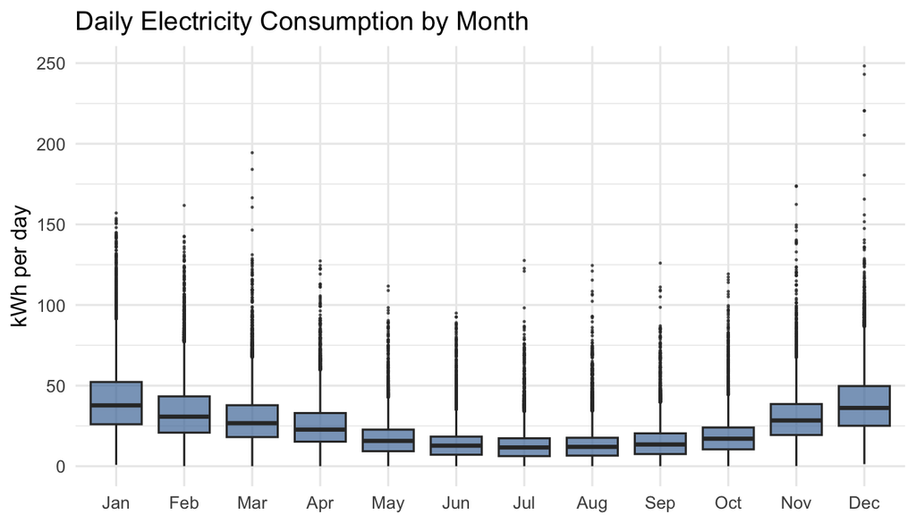

```r
heapo %>%
  mutate(Month = month(date, label = TRUE, abbr = TRUE)) %>%
  ggplot(aes(x = Month, y = kWh_total)) +
  geom_boxplot(fill = clr_primary, alpha = 0.7, outlier.size = 0.2) +
  scale_y_continuous(labels = comma) +
  labs(
    title = "Daily Electricity Consumption by Month",
    x = NULL,
    y = "kWh per day"
  ) +
  report_theme
```

## 2.2 Heating Degree Days vs. Consumption

**Heating Degree Days (HDD)** quantify daily heating demand as the temperature shortfall below the 12°C Swiss SIA base temperature. A day averaging 2°C contributes 10 HDD, days above 12°C contribute zero. HDD is a more direct proxy for heat pump workload than raw outdoor temperature.

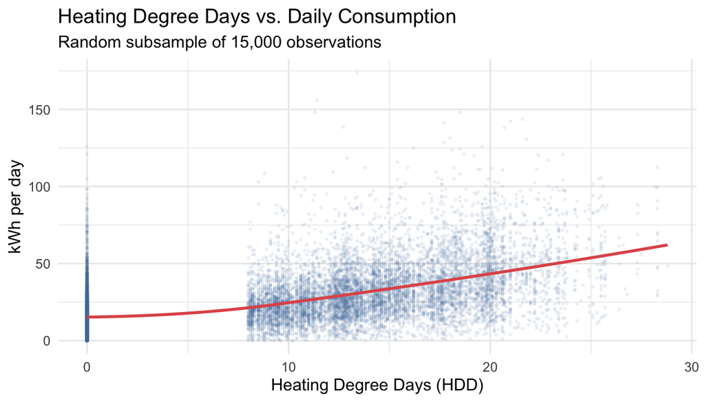

```r
heapo %>%
  slice_sample(n = 15000) %>%
  ggplot(aes(x = heating_degree_days, y = kWh_total)) +
  geom_point(alpha = 0.08, size = 0.5, color = clr_primary) +
  geom_smooth(
    method = "loess",
    color = clr_secondary,
    se = FALSE,
    linewidth = 1
  ) +
  scale_y_continuous(labels = comma) +
  labs(
    title = "Heating Degree Days vs. Daily Consumption",
    subtitle = "Random subsample of 15,000 observations",
    x = "Heating Degree Days (HDD)",
    y = "kWh per day"
  ) +
  report_theme
```

## 2.3 Consumption by Building Type

Houses consume substantially more electricity per day than apartments, with medians differing by roughly a factor of two. This gap persists after controlling for weather, as the modelling section will confirm. Building type therefore carries real structural signal and is included as a predictor in all models.

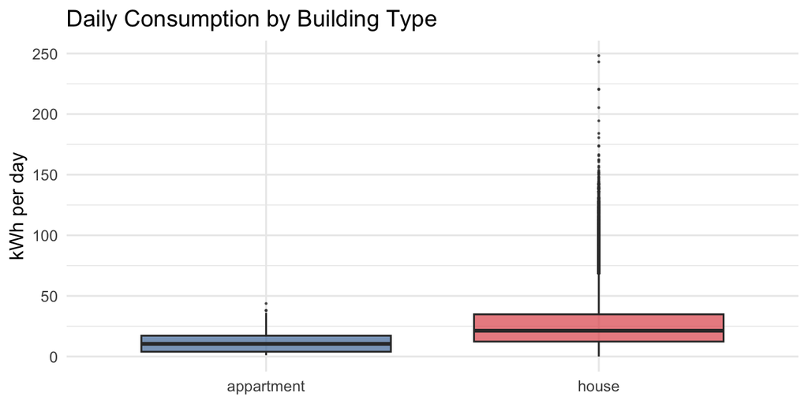

```r
heapo %>%
  ggplot(aes(x = building_type, y = kWh_total, fill = building_type)) +
  geom_boxplot(alpha = 0.7, outlier.size = 0.2) +
  scale_y_continuous(labels = comma) +
  scale_fill_manual(values = clr_builds, guide = "none") +
  labs(
    title = "Daily Consumption by Building Type",
    x = NULL,
    y = "kWh per day"
  ) +
  report_theme
```

Taken together, the three plots tell a consistent story. Electricity demand is primarily a seasonal phenomenon. The portfolio shifts from a low-consumption summer baseline driven by domestic appliances to a high-consumption winter regime dominated by heat pump space heating. Within that seasonal pattern, building type is the strongest structural separator, with houses drawing roughly twice the daily energy of apartments at any given temperature. These findings directly shape the modelling choices below. The response is log-transformed to stabilise variance, heating degree days enter as the primary continuous weather predictor, and building type is retained as a categorical covariate in every model. For the client, the key implication is that cold spells and the building stock composition of a supply portfolio are the two dominant levers of aggregate demand, and any forecasting tool must capture both to be useful.

# 3 Modelling

Six models are fitted to the HEAPO data, each targeting a response variable suited to its statistical family. The Linear Model and Generalised Additive Model are fitted to `log_kWh_total`, the log-transformed daily electricity consumption. The GLM Binomial, Neural Network, and Support Vector Machine all classify household-days as high or low consumption using each household’s own 75th percentile as the threshold, capturing the top 25% of days for each individual household. The GLM Poisson models the monthly count of high-consumption days per household, capturing longer-term demand patterns at a coarser aggregation. Model performance is evaluated in the comparison section: regression models are compared via five-fold cross-validation MAE in kWh and R²; classification models via AUC and accuracy.

## 3.1 Linear Model (LM)

*Lead: Tharrmeehan Krishnathasan*

```r
heapo_lm <- readRDS("../models/linear_model/heapo_lm.rds")

mlm_simple_path <- "../models/linear_model/heapo_mlm_simple.rds"
if (file.exists(mlm_simple_path)) {
  heapo_mlm_simple <- readRDS(mlm_simple_path)
} else {
  heapo_mlm_simple <- lm(
    log_kWh_total ~ heating_degree_days +
      sunshine_hours +
      humidity_avg +
      living_area +
      n_residents +
      building_type +
      heatpump_type,
    data = heapo
  )
  saveRDS(heapo_mlm_simple, mlm_simple_path)
}
```

### 3.1.1 Objective

Can a simple regression explain how much electricity a household uses on a given day? This section fits a multiple linear regression to `log_kWh_total`, the natural logarithm of daily kilowatt-hour usage. The log transformation is standard for energy data: raw daily kWh is strictly positive and right-skewed, and the log scale is approximately normal. Coefficients on the log scale are directly readable as approximate percentage changes in consumption, which matters for communicating load drivers to grid operators and energy suppliers.

Predictors cover weather conditions (heating degree days, sunshine hours, humidity), building characteristics (building type, living area, heat pump type), and household composition (number of residents). A simple additive model is estimated first as an interpretable baseline. Two interaction terms are then added: one testing whether cold-weather sensitivity differs between houses and apartments, and one testing whether it differs between heat pump technologies. Both are motivated by domain knowledge: houses lose heat faster through larger surface areas, and ground-source heat pumps maintain higher efficiency in cold weather than air-source systems.

### 3.1.2 Model Setup

Two models are estimated:

**Simple MLR:** all seven predictors with main effects only, as an interpretable baseline for the additive relationships between predictors and log energy consumption:

$$\log(\text{kWh}_i) = \beta_0 + \beta_1\,\text{HDD}_i +
\beta_2\,\text{Sunshine}_i + \cdots + \beta_7\,\text{HeatpumpType}_i +
\varepsilon_i$$

**Extended MLR:** adds two interaction terms:

- `heating_degree_days` × `heatpump_type` (cold-weather sensitivity by pump technology)
- `heating_degree_days` × `building_type` (cold-weather sensitivity by building type)

All coefficients are on the log scale: a coefficient of 0.05 means a 5% multiplicative change in kWh for a one-unit increase in the predictor.

### 3.1.3 Model Results

**Show / hide table**

```r
tidy(heapo_lm) %>%
  filter(term != "(Intercept)") %>%
  mutate(
    estimate = round(estimate, 4),
    std.error = round(std.error, 4),
    statistic = round(statistic, 2),
    p.value = signif(p.value, 3)
  ) %>%
  knitr::kable(
    col.names = c("Predictor", "Estimate", "Std. Error", "t value", "p value"),
    caption = "Extended MLR: coefficient estimates"
  ) %>%
  kable_styling(bootstrap_options = c("striped", "hover"), full_width = TRUE)
```

Extended MLR: coefficient estimates

| Predictor | Estimate | Std. Error | t value | p value |
| --- | --- | --- | --- | --- |
| heating_degree_days | 0.0212 | 0.0029 | 7.42 | 0.000000 |
| building_typehouse | 0.2199 | 0.0329 | 6.68 | 0.000000 |
| heatpump_typeground-source | -0.1427 | 0.0085 | -16.79 | 0.000000 |
| sunshine_hours | -0.0154 | 0.0009 | -16.62 | 0.000000 |
| humidity_avg | 0.0005 | 0.0003 | 1.39 | 0.165000 |
| living_area | 0.0004 | 0.0000 | 9.78 | 0.000000 |
| n_residents | 0.1336 | 0.0026 | 50.88 | 0.000000 |
| heating_degree_days:building_typehouse | 0.0392 | 0.0029 | 13.72 | 0.000000 |
| heating_degree_days:heatpump_typeground-source | -0.0027 | 0.0007 | -3.63 | 0.000283 |

All predictors are significant at the 0.001 level except `humidity_avg` (p = 0.165), which adds nothing once the other weather variables are included. Effects on log energy consumption, holding all other variables constant:

**Heating degree days** (β = 0.021, p < 0.001): Each additional HDD increases log consumption by ~2.1% for air-source pump households in apartments (the baseline group).

**Sunshine hours** (β = −0.015, p < 0.001): An additional sunshine hour reduces consumption by ~1.5%, reflecting lower heating demand on brighter days.

**Number of residents** (β = 0.134, p < 0.001): Each additional resident increases consumption by ~14.3% ($e^{0.134} - 1$), the largest per-unit effect among continuous predictors in the model.

**Building type — house** (β = 0.220, p < 0.001): Houses consume ~24.6% more than apartments at baseline, before accounting for their greater sensitivity to cold (see interaction below).

**Heat pump type — ground-source** (β = −0.143, p < 0.001): Ground-source pump households consume ~13.3% less than air-source households at the baseline temperature.

**Interaction: HDD × house** (β = 0.039, p < 0.001): Houses are substantially *more* sensitive to cold than apartments: each additional HDD adds 3.9% to log consumption, the largest interaction effect in the model.

**Interaction: HDD × ground-source** (β = −0.003, p < 0.001): Ground-source pump households are slightly *less* sensitive to cold than air-source households, consistent with the higher efficiency of ground-source systems at low outdoor temperatures.

### 3.1.4 Visual Evidence

The coefficient plot below shows each predictor’s estimated coefficient with 95% confidence intervals. A coefficient to the right of zero increases daily consumption; one to the left reduces it. Grey points whose intervals cross zero are not statistically significant.

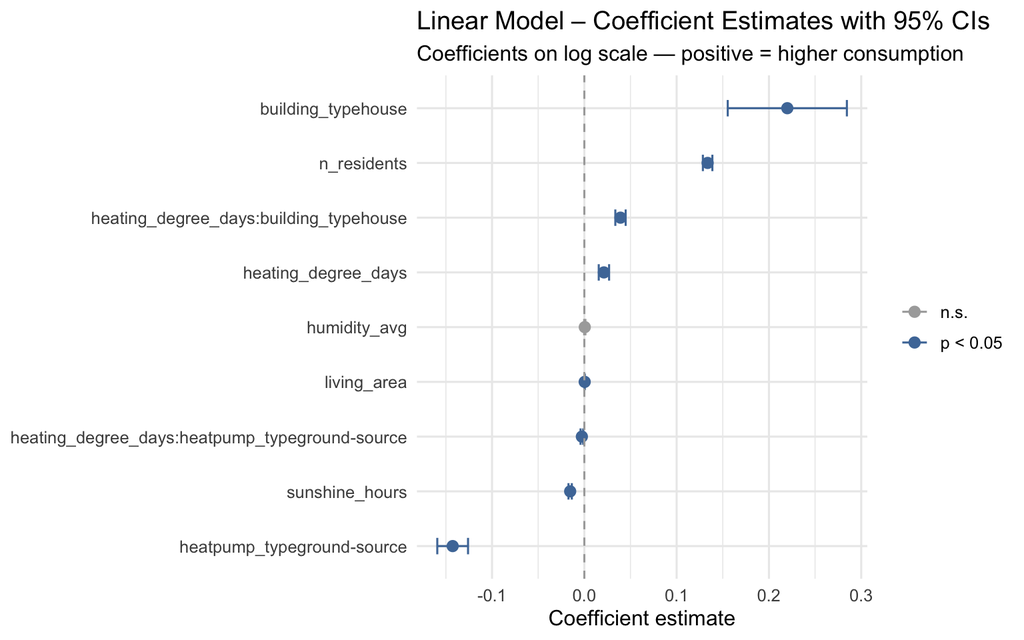

```r
cis <- confint(heapo_lm)

coef_df <- tibble(
  term = names(coef(heapo_lm)),
  estimate = coef(heapo_lm),
  lower = cis[, 1],
  upper = cis[, 2]
) %>%
  filter(term != "(Intercept)") %>%
  mutate(significant = !(lower < 0 & upper > 0))

ggplot(
  coef_df,
  aes(x = estimate, y = reorder(term, estimate), color = significant)
) +
  geom_point(size = 2.5) +
  geom_errorbarh(aes(xmin = lower, xmax = upper), height = 0.3) +
  geom_vline(xintercept = 0, linetype = "dashed", color = clr_neutral) +
  scale_color_manual(
    values = c("FALSE" = clr_neutral, "TRUE" = clr_primary),
    labels = c("n.s.", "p < 0.05")
  ) +
  report_theme +
  labs(
    title = "Linear Model – Coefficient Estimates with 95% CIs",
    subtitle = "Coefficients on log scale — positive = higher consumption",
    x = "Coefficient estimate",
    y = NULL,
    color = NULL
  )
```

`building_typehouse` sits furthest to the right (β = 0.220), confirming the large baseline gap between houses and apartments. `n_residents` follows (β = 0.134), reflecting strong occupancy effects. The HDD-by-house interaction (β = 0.039) sits third, showing that houses also respond more steeply to cold. Ground-source heat pump households are below zero on both the main effect and the interaction, consistent with their efficiency advantage. `humidity_avg` is the only predictor whose interval crosses zero.

The scatterplot of observed versus fitted values on the log scale shows the model’s overall predictive calibration. A perfectly calibrated model would scatter all points along the 1:1 diagonal; systematic deviations above or below the line indicate regions where the model consistently over- or under-predicts.

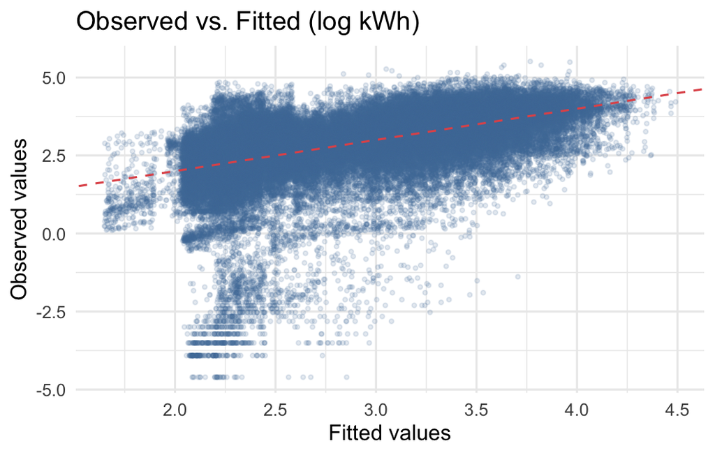

```r
fit_df <- tibble(
  fitted = fitted(heapo_lm),
  observed = heapo$log_kWh_total[as.integer(names(fitted(heapo_lm)))]
)

ggplot(fit_df, aes(x = fitted, y = observed)) +
  geom_point(alpha = 0.15, size = 0.8, color = clr_primary) +
  geom_abline(
    slope = 1,
    intercept = 0,
    color = clr_secondary,
    linetype = "dashed"
  ) +
  report_theme +
  labs(
    title = "Observed vs. Fitted (log kWh)",
    x = "Fitted values",
    y = "Observed values"
  )
```

### 3.1.5 Model Diagnostics

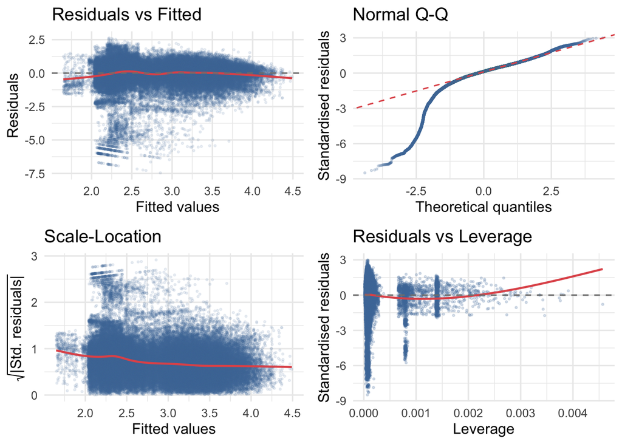

```r
aug <- broom::augment(heapo_lm)

p1 <- ggplot(aug, aes(x = .fitted, y = .resid)) +
  geom_point(alpha = 0.1, size = 0.5, color = clr_primary) +
  geom_smooth(
    method = "gam",
    se = FALSE,
    color = clr_secondary,
    linewidth = 0.8
  ) +
  geom_hline(yintercept = 0, linetype = "dashed", color = "grey50") +
  labs(title = "Residuals vs Fitted", x = "Fitted values", y = "Residuals") +
  report_theme

p2 <- ggplot(aug, aes(sample = .std.resid)) +
  stat_qq(alpha = 0.2, size = 0.5, color = clr_primary) +
  stat_qq_line(color = clr_secondary, linetype = "dashed") +
  labs(
    title = "Normal Q-Q",
    x = "Theoretical quantiles",
    y = "Standardised residuals"
  ) +
  report_theme

p3 <- ggplot(aug, aes(x = .fitted, y = sqrt(abs(.std.resid)))) +
  geom_point(alpha = 0.1, size = 0.5, color = clr_primary) +
  geom_smooth(
    method = "gam",
    se = FALSE,
    color = clr_secondary,
    linewidth = 0.8
  ) +
  labs(
    title = "Scale-Location",
    x = "Fitted values",
    y = expression(sqrt("|Std. residuals|"))
  ) +
  report_theme

p4 <- ggplot(aug, aes(x = .hat, y = .std.resid)) +
  geom_point(alpha = 0.2, size = 0.5, color = clr_primary) +
  geom_smooth(
    method = "gam",
    se = FALSE,
    color = clr_secondary,
    linewidth = 0.8
  ) +
  geom_hline(yintercept = 0, linetype = "dashed", color = "grey50") +
  labs(
    title = "Residuals vs Leverage",
    x = "Leverage",
    y = "Standardised residuals"
  ) +
  report_theme

gridExtra::grid.arrange(p1, p2, p3, p4, ncol = 2)
```

The four panels assess the core OLS assumptions. *Residuals vs. Fitted* checks for leftover non-linearity after fitting; a flat smoother near zero indicates no major pattern has been missed. *Normal Q-Q* checks whether residuals are approximately normal, which matters for the validity of p-values. *Scale-Location* checks for heteroscedasticity; a rising smoother would mean larger fitted values have more variable errors. *Residuals vs. Leverage* checks whether any single observation is pulling the estimates far from where the rest of the data would place them.

One assumption the plots cannot fully address is independence. The dataset contains many observations per household, so residuals from the same household are correlated. Standard errors are consequently understated to some degree, and significance levels should be read with that caveat.

**Show / hide table**

```r
vif_vals <- vif(heapo_lm)
data.frame(
  Predictor = names(vif_vals),
  VIF = round(as.numeric(vif_vals), 2)
) %>%
  knitr::kable(
    caption = "Variance Inflation Factors (VIF) — extended model"
  ) %>%
  kable_styling(bootstrap_options = c("striped", "hover"), full_width = TRUE)
```

Variance Inflation Factors (VIF) — extended model

| Predictor | VIF |
| --- | --- |
| heating_degree_days | 61.55 |
| building_type | 2.18 |
| heatpump_type | 2.15 |
| sunshine_hours | 2.28 |
| humidity_avg | 2.09 |
| living_area | 1.04 |
| n_residents | 1.03 |
| heating_degree_days:building_type | 61.44 |
| heating_degree_days:heatpump_type | 2.86 |

Most predictors have VIF below 3, indicating no problematic multicollinearity. The exception is `heating_degree_days` (VIF = 61.55) and its interaction with `building_typehouse` (VIF = 61.44). These elevated values are expected when a predictor appears in both a main effect and an interaction, and do not invalidate the model. The coefficients remain highly significant despite the inflated standard errors.

```r
df_lm_cv <- heapo %>%
  select(
    log_kWh_total,
    heating_degree_days,
    sunshine_hours,
    humidity_avg,
    living_area,
    n_residents,
    building_type,
    heatpump_type
  ) %>%
  na.omit() %>%
  as.data.frame()

set.seed(42)
folds_lm <- caret::createFolds(df_lm_cv$log_kWh_total, k = 5, list = TRUE)

cv_lm <- lapply(folds_lm, function(test_idx) {
  train <- df_lm_cv[-test_idx, ]
  test <- df_lm_cv[test_idx, ]

  simple_fit <- lm(
    log_kWh_total ~ heating_degree_days +
      sunshine_hours +
      humidity_avg +
      living_area +
      n_residents +
      building_type +
      heatpump_type,
    data = train
  )
  ext_fit <- lm(
    log_kWh_total ~ heating_degree_days *
      building_type +
      heating_degree_days * heatpump_type +
      sunshine_hours +
      humidity_avg +
      living_area +
      n_residents,
    data = train
  )

  actual_kwh <- exp(test$log_kWh_total)
  list(
    simple_mae = mean(abs(
      actual_kwh - exp(predict(simple_fit, newdata = test))
    )),
    ext_mae = mean(abs(actual_kwh - exp(predict(ext_fit, newdata = test))))
  )
})

lm_simple_cv_mae <- mean(sapply(cv_lm, `[[`, "simple_mae"))
lm_ext_cv_mae <- mean(sapply(cv_lm, `[[`, "ext_mae"))
```

**Show / hide table**

```r
tibble(
  Model = c("Simple MLR (main effects)", "Extended MLR (+ interactions)"),
  `Adj. R²` = c(
    round(summary(heapo_mlm_simple)$adj.r.squared, 4),
    round(summary(heapo_lm)$adj.r.squared, 4)
  ),
  `CV MAE (kWh/day)` = c(
    round(lm_simple_cv_mae, 2),
    round(lm_ext_cv_mae, 2)
  )
) %>%
  knitr::kable(
    caption = "LM model comparison — Adj. R² on full data; MAE from 5-fold CV"
  ) %>%
  kable_styling(bootstrap_options = c("striped", "hover"), full_width = TRUE)
```

LM model comparison — Adj. R² on full data; MAE from 5-fold CV

| Model | Adj. R² | CV MAE (kWh/day) |
| --- | --- | --- |
| Simple MLR (main effects) | 0.2727 | 10.97 |
| Extended MLR (+ interactions) | 0.2743 | 10.96 |

The simple model achieves an adjusted R² of 0.2727. Adding the two interaction terms improves this to 0.2743, and 5-fold cross-validation confirms the pattern holds out-of-sample: MAE drops from 10.97 to 10.96 kWh/day. The gain from allowing cold-weather sensitivity to vary by group is real but small in absolute terms. Overall explanatory power is modest because weather and building characteristics capture only the structural drivers of consumption. Day-to-day variation driven by whether someone is home or what appliances are running is not in the dataset, and represents a natural ceiling for any model of this kind.

### 3.1.6 Key Findings

**Heating degree days is the dominant weather driver:** Cold weather is the primary positive predictor of energy consumption. Houses start from a higher baseline (β = 0.220) and are more sensitive to cold than apartments (interaction β = 0.039, p < 0.001), consistent with lower thermal efficiency.

**Household size has the strongest continuous predictor effect:** With β = 0.134, each additional resident increases daily consumption by ~14.3%, the largest per-unit effect among continuous predictors in the model.

**Ground-source heat pumps are more efficient and more stable:** They consume ~13.3% less at baseline and respond less to temperature swings (interaction β = −0.003), consistent with the efficiency advantage of ground-source systems at low outdoor temperatures.

**Humidity is not a useful predictor:** `humidity_avg` is not significant (p = 0.165) once the other weather variables are controlled for.

**Overall explanatory power is limited:** The extended model explains ~27.4% of the variance in log daily consumption (adj. R² = 0.2743). On the original kWh scale, mean absolute error is 11 kWh/day (5-fold CV). Household-level heterogeneity is the likely cause; models with household-level random effects would be needed for operational forecasting.

## 3.2 GLM – Poisson

*Lead: Raphaël Spagolla*

### 3.2.1 Objective

The aim of this analysis is to model the number of high-consumption days per household-month ($n_{high\ days}$). This variable represents count data, taking non-negative integer values. A plain linear model is not appropriate here, as it assumes normally distributed errors and can produce negative predictions — both of which are incompatible with count outcomes.

A Poisson Generalised Linear Model (GLM) is used instead, as it is specifically designed for non-negative integer outcomes and naturally allows the variance to grow with the mean. By including an offset for the number of observed days, the model estimates rates, allowing interpretation of results in terms of relative changes (rate ratios).

### 3.2.2 Model Setup

**Show / hide result**

```r
print(formula(mod_pois))
```

```
## n_high_days ~ heating_degree_days + temp_avg + living_area +
##     building_type + heatpump_type + has_floor_heating + n_residents +
##     share_weekend
```

The response variable is the number of high-consumption days per household-month ($n_{high\ days}$). A day is classified as a high-consumption day if its daily `log_kWh_total` exceeds that household’s own 75th percentile, consistent with the threshold used in the GLM Binomial and throughout the report. Because the number of observed days can vary slightly across household–months, the model includes the logarithm of the observed days $(\log(n_{days}))$ as an offset. This adjustment effectively converts the outcome into a rate — high-consumption days per observed day — so that observations remain comparable even when exposure differs between months.

To model these rates, a Poisson GLM with a log-link is fitted:

$$\log(\mathbb{E}[Y_i]) = \beta_0 + \beta_1 X_{1i} + \cdots + \beta_p
X_{pi} + \log(n_{\text{days},i})$$

The log-link guarantees positive fitted values and supports a multiplicative interpretation of effects.

One predictor warrants clarification: `share_weekend` is the monthly proportion of weekend days within a household–month (a continuous value between 0 and 1), and is distinct from the daily binary `is_weekend` flag used in the GLM Binomial and other daily-level models.

### 3.2.3 Model Results

The results are interpreted in terms of *percentage changes in the expected rate*, holding all other variables constant.

**Building type (house vs apartments):** Households living in houses have a rate of high-consumption days approximately 363% higher than those living in apartments $((4.632 - 1) \times 100\%)$. This is by far the strongest effect in the model, clearly visible in the boxplot, and indicates that building type is the dominant structural driver of consumption patterns.

**Average temperature:** The rate ratio of 0.915 implies that each additional degree Celsius is associated with an 8.5% decrease in the expected rate of high- consumption days $((1 - 0.915) \times 100\%)$. This reflects reduced heating needs at warmer temperatures, consistent with the strong negative trend visible in the scatterplot.

**Heating degree days:** The rate ratio is marginally below 1 ($\approx$ 0.999) and not statistically significant. Once average temperature is already in the model, heating degree days add little additional explanatory power, as both variables capture overlapping thermal information. This collinearity explains why the coefficient is effectively zero.

**Number of residents:** Each additional household member increases the expected rate by approximately 8.9% $((1.089 - 1) \times 100\%)$. This reflects the intuitive result that larger households consume more energy overall.

**Living area:** The rate ratio of 1.001 indicates a statistically significant but practically small positive effect — each additional square metre increases the expected rate by about 0.1%. The effect accumulates for larger dwellings but remains modest compared to building type or household size.

**Ground-source heat pump:** Households equipped with a ground-source heat pump show a rate approximately 9.3% lower than the reference heat pump type $((1 - 0.907) \times 100\%)$. This is consistent with ground-source systems being more energy-efficient, particularly during colder periods.

**Floor heating:** Households with floor heating show a rate approximately 13% higher than those without $((1.130 - 1) \times 100\%)$. This likely reflects the greater energy input required by radiant floor systems to maintain comfort temperatures.

**Weekend share:** This predictor has a very wide confidence interval and is non-significant once overdispersion is accounted for (quasi-Poisson p > 0.05). The direction of the raw Poisson estimate should not be interpreted. The two models are not directly comparable on this predictor, as they operate at different aggregation levels.

Overall, structural and household characteristics (building type, size, and number of residents) exhibit the strongest and most reliable effects, while temperature captures an important environmental influence.

### 3.2.4 Visual Evidence

To complement the model output, the plots below provide direct visual support for the main relationships in the data.

The *scatterplot of high-consumption days versus average temperature* reveals a strong and consistent negative pattern. At temperatures near 0°C, many households record close to 30 high-consumption days, whereas above 15°C the counts concentrate near zero. The smooth LOESS curve decreases steeply in the 0–10°C range and flattens at higher temperatures, suggesting diminishing marginal effects of warmth once heating demand is already low.

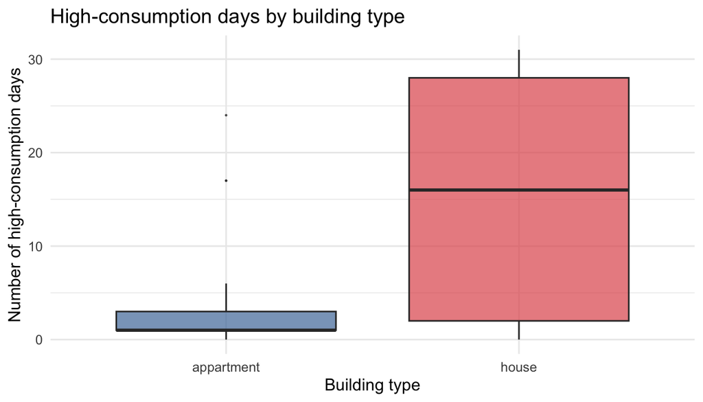

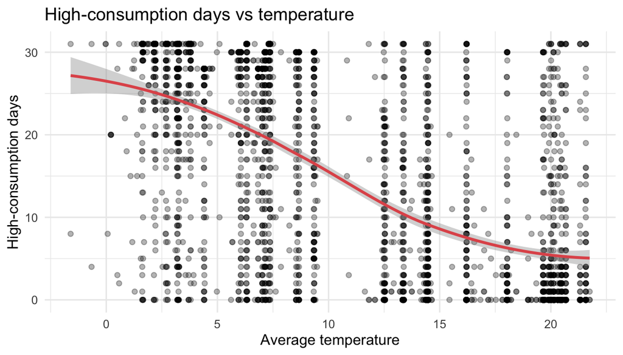

```r
ggplot(
  dat_count,
  aes(x = building_type, y = n_high_days, fill = building_type)
) +
  geom_boxplot(alpha = 0.7, outlier.size = 0.2) +
  scale_fill_manual(values = clr_builds, guide = "none") +
  labs(
    title = "High-consumption days by building type",
    x = "Building type",
    y = "Number of high-consumption days"
  ) +
  report_theme

ggplot(dat_count, aes(x = temp_avg, y = n_high_days)) +
  geom_point(alpha = 0.3) +
  geom_smooth(method = "loess", color = clr_secondary) +
  labs(
    title = "High-consumption days vs temperature",
    x = "Average temperature",
    y = "High-consumption days"
  ) +
  report_theme
```

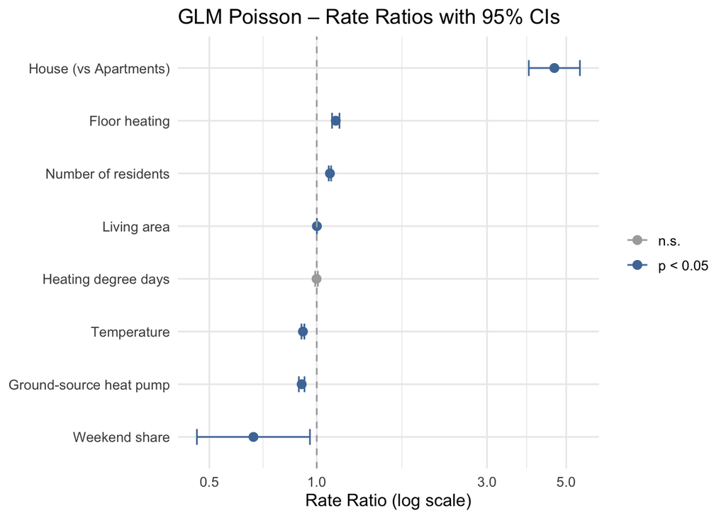

```r
coef_summary <- coef(summary(mod_pois))

coef_df <- data.frame(
  term = rownames(coef_summary),
  estimate = coef_summary[, "Estimate"],
  se = coef_summary[, "Std. Error"],
  p_value = coef_summary[, "Pr(>|z|)"]
)

coef_df <- coef_df[coef_df$term != "(Intercept)", ]

coef_df$rate_ratio <- exp(coef_df$estimate)
coef_df$ci_low <- exp(coef_df$estimate - 1.96 * coef_df$se)
coef_df$ci_high <- exp(coef_df$estimate + 1.96 * coef_df$se)
coef_df$significant <- coef_df$p_value < 0.05

coef_df$term <- dplyr::recode(
  coef_df$term,
  "temp_avg" = "Temperature",
  "living_area" = "Living area",
  "building_typehouse" = "House (vs Apartments)",
  "heatpump_typeground-source" = "Ground-source heat pump",
  "has_floor_heating1" = "Floor heating",
  "n_residents" = "Number of residents",
  "share_weekend" = "Weekend share",
  "heating_degree_days" = "Heating degree days"
)

ggplot(
  coef_df,
  aes(x = rate_ratio, y = reorder(term, rate_ratio), color = significant)
) +
  geom_point(size = 2.5) +
  geom_errorbarh(aes(xmin = ci_low, xmax = ci_high), height = 0.3) +
  geom_vline(xintercept = 1, linetype = "dashed", color = clr_neutral) +
  scale_color_manual(
    values = c("FALSE" = clr_neutral, "TRUE" = clr_primary),
    labels = c("n.s.", "p < 0.05")
  ) +
  scale_x_log10() +
  labs(
    title = "GLM Poisson – Rate Ratios with 95% CIs",
    x = "Rate Ratio (log scale)",
    y = NULL,
    color = NULL
  ) +
  report_theme
```

### 3.2.5 Model Diagnostics

```r
s_m_p <- summary(mod_pois)
disp_pois <- s_m_p$deviance / s_m_p$df.residual

s_m_q <- summary(mod_quasi_pois)
phi_q <- sum(residuals(mod_quasi_pois, type = "pearson")^2) /
  df.residual(mod_quasi_pois)

p_pois <- coef(summary(mod_pois))[, 4]
p_quasi <- coef(summary(mod_quasi_pois))[, 4]
```

A key assumption of the Poisson GLM is *equidispersion*, i.e., that the conditional variance equals the conditional mean. We assess this by comparing the residual deviance to the residual degrees of freedom. For the fitted Poisson model, the residual deviance is 27,529.6 on 3291 df, yielding a ratio of 8.37. Since this substantially exceeds 1, there is strong evidence of *overdispersion* — the Poisson model underestimates standard errors and overstates statistical significance.

We therefore refit the model using a *quasi-Poisson* family, which retains identical point estimates but inflates standard errors by $\sqrt{\hat{\phi}}$ ($\hat{\phi}$ = 7.74), yielding more conservative and reliable inference. The most visible consequence is that *weekend share* shifts from significant under Poisson (p = 0.028) to clearly non-significant under quasi-Poisson (p = 0.43), indicating that this effect should not be over-interpreted.

The table and plot below show the SE inflation across all predictors. The effect is proportional — predictors with larger SEs to begin with (e.g., *weekend share*, *house vs apartments*) show the largest absolute increase, while those with very small SEs (e.g., *living area*, *number of residents*) are inflated by a smaller absolute amount but the same factor $\sqrt{\hat{\phi}}$.

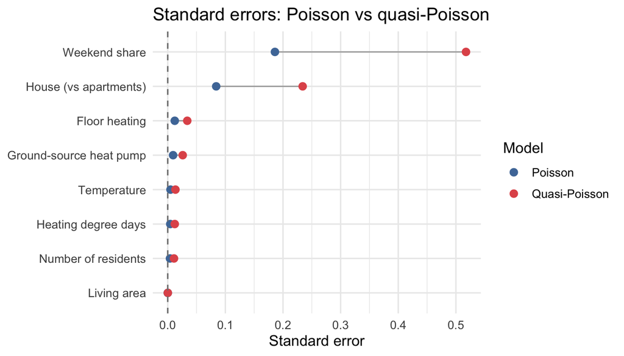

```r
pois_tidy <- tidy(mod_pois) %>% select(term, estimate, std.error, p.value)
quasi_tidy <- tidy(mod_quasi_pois) %>% select(term, std.error, p.value)

comp_table <- pois_tidy %>%
  filter(term != "(Intercept)") %>%
  rename(se_pois = std.error, pval_pois = p.value) %>%
  left_join(
    quasi_tidy %>%
      filter(term != "(Intercept)") %>%
      rename(se_quasi = std.error, pval_quasi = p.value),
    by = "term"
  ) %>%
  mutate(
    term = dplyr::recode(
      term,
      "temp_avg" = "Temperature",
      "living_area" = "Living area",
      "building_typehouse" = "House (vs apartments)",
      "heatpump_typeground-source" = "Ground-source heat pump",
      "has_floor_heating1" = "Floor heating",
      "n_residents" = "Number of residents",
      "share_weekend" = "Weekend share",
      "heating_degree_days" = "Heating degree days"
    ),
    se_pois = round(se_pois, 4),
    se_quasi = round(se_quasi, 4)
  )

comp_long <- comp_table %>%
  mutate(se_diff = se_quasi - se_pois) %>%
  arrange(se_diff) %>%
  mutate(term = factor(term, levels = term)) %>%
  pivot_longer(
    cols = c(se_pois, se_quasi),
    names_to = "model",
    values_to = "se"
  ) %>%
  mutate(model = ifelse(model == "se_pois", "Poisson", "Quasi-Poisson"))

ggplot(comp_long, aes(x = se, y = term, colour = model)) +
  geom_line(aes(group = term), colour = clr_neutral, linewidth = 0.5) +
  geom_point(size = 2.5) +
  scale_colour_manual(
    values = c("Poisson" = clr_primary, "Quasi-Poisson" = clr_secondary)
  ) +
  geom_vline(xintercept = 0, linetype = "dashed", colour = "grey50") +
  labs(
    title = "Standard errors: Poisson vs quasi-Poisson",
    x = "Standard error",
    y = NULL,
    colour = "Model"
  ) +
  report_theme
```

### 3.2.6 Goodness of Fit

To assess predictive accuracy, we compare fitted values against observed counts and report the Root Mean Squared Error (RMSE). The observed-vs-fitted plot is rendered as a hexbin to handle overplotting given the large number of observations.

**Show / hide result**

```r
dat_count$fitted_pois <- fitted(mod_pois)
dat_count$fitted_quasi <- fitted(mod_quasi_pois)

rmse_pois <- sqrt(mean((dat_count$n_high_days - dat_count$fitted_pois)^2))
rmse_quasi <- sqrt(mean((dat_count$n_high_days - dat_count$fitted_quasi)^2))

knitr::kable(
  data.frame(
    Model = "Poisson",
    RMSE = round(rmse_pois, 3)
  ),
  caption = "Root Mean Squared Error for the Poisson model."
) %>%
  kable_styling(bootstrap_options = c("striped", "hover"), full_width = TRUE)
```

Root Mean Squared Error for the Poisson model.

| Model | RMSE |
| --- | --- |
| Poisson | 9.452 |

The RMSE of 9.452 days reflects substantial residual spread, partly explained by the high overdispersion ($\hat{\phi}$ = 7.74). Note that the quasi-Poisson model produces identical fitted values and therefore the same RMSE, as it only affects standard errors and inference, not point predictions.

### 3.2.7 Key Findings

The Poisson GLM provides a clear and interpretable account of the factors driving the frequency of high-consumption days. Building type, temperature, and household size emerge as the strongest and most robust predictors, consistent with both domain knowledge and the exploratory analysis.

However, a dispersion ratio of 8.37 confirms substantial overdispersion, making standard Poisson inference unreliable. The quasi-Poisson model corrects for this by inflating standard errors appropriately, leading to more conservative and trustworthy conclusions — most notably, the loss of significance for weekend share.

While the quasi-Poisson model improves inference, a negative binomial model could be considered as a more flexible alternative, as it models the overdispersion through an explicit distributional parameter rather than a post- hoc correction.

## 3.3 GLM – Binomial

*Lead: Emanuel Lemma*

### 3.3.1 Objective

Can we predict whether a given day will be unusually high-consumption for a specific household? This section fits a Generalised Linear Model with a binomial family to answer exactly that question. The response variable `high_consumption` is a binary indicator that equals 1 if the household’s daily `log_kWh_total` exceeds that household’s own 75th percentile and 0 otherwise. Using a per-household threshold means the model is not distinguishing houses from apartments. Each household’s own consumption baseline is already accounted for. Instead, the model learns what drives a day to be in the top 25% for a given household, regardless of its size or type. By modelling the log-odds of high consumption as a linear function of weather conditions, building characteristics, and calendar effects, we obtain a model that is both interpretable and actionable for a client interested in understanding what drives demand spikes at the household level.

### 3.3.2 Model Setup

```r
set.seed(42)

hh_q75 <- heapo |>
  group_by(Household_ID) |>
  summarise(
    hh_q75 = quantile(log_kWh_total, 0.75, na.rm = TRUE),
    .groups = "drop"
  )

df_glm <- heapo |>
  left_join(hh_q75, by = "Household_ID") |>
  mutate(
    high_consumption = as.integer(log_kWh_total >= hh_q75),
    month = as.factor(month)
  ) |>
  select(
    high_consumption,
    heating_degree_days,
    temp_avg,
    living_area,
    building_type,
    heatpump_type,
    has_floor_heating,
    n_residents,
    is_weekend,
    month
  ) |>
  drop_na()

train_idx <- sample(nrow(df_glm), 0.8 * nrow(df_glm))
train_df <- df_glm[train_idx, ]
test_df <- df_glm[-train_idx, ]
```

```r
if (!file.exists("../models/glm_binomial/glm_binomial_hh_q75.rds")) {
  model_glm <- glm(high_consumption ~ ., data = train_df, family = binomial)
  saveRDS(model_glm, "../models/glm_binomial/glm_binomial_hh_q75.rds")
} else {
  model_glm <- readRDS("../models/glm_binomial/glm_binomial_hh_q75.rds")
}
```

For each of the 127 households, the 75th percentile of their `log_kWh_total` is computed and used as that household’s personal high-consumption threshold. A day is labelled 1 if it falls in the top 25% of that household’s own consumption distribution. By construction, every household contributes exactly 25% high-consumption days, so building type and household size are absorbed into the threshold and do not mechanically drive the outcome. The dataset is restricted to nine predictors covering weather conditions, building characteristics, and calendar effects, then split into 80% training and 20% test sets. The model is fitted with `glm()` using `family = binomial`, which models the log-odds of high consumption as a linear combination of predictors. The saved model is reloaded on subsequent knits to avoid refitting.

### 3.3.3 Model Results

```r
pred_prob <- predict(model_glm, newdata = test_df, type = "response")
pred_class <- ifelse(pred_prob >= 0.5, 1L, 0L)
actual <- test_df$high_consumption

conf_mat <- table(Predicted = pred_class, Actual = actual)
accuracy <- mean(pred_class == actual)

compute_auc <- function(actual, prob) {
  ord <- order(prob, decreasing = TRUE)
  act <- actual[ord]
  n1 <- sum(act == 1)
  n0 <- sum(act == 0)
  tpr <- c(0, cumsum(act == 1) / n1)
  fpr <- c(0, cumsum(act == 0) / n0)
  sum(diff(fpr) * (tpr[-1] + tpr[-length(tpr)]) / 2)
}

glm_auc_val <- compute_auc(actual, pred_prob)
tp <- conf_mat["1", "1"]
tn <- conf_mat["0", "0"]
fp <- conf_mat["1", "0"]
fn <- conf_mat["0", "1"]
precision <- tp / (tp + fp)
recall <- tp / (tp + fn)
f1 <- 2 * precision * recall / (precision + recall)
specificity <- tn / (tn + fp)
```

Coefficients from a binomial GLM are expressed as odds ratios (OR = exp(coefficient)). A value above 1 increases the odds that a day falls in the top 25% of a household’s own consumption, and a value below 1 decreases it, relative to the reference category.

**Show / hide table**

```r
glm_cs <- coef(summary(model_glm))
glm_tbl <- data.frame(
  Term = rownames(glm_cs),
  Estimate = round(glm_cs[, "Estimate"], 3),
  OR = round(exp(glm_cs[, "Estimate"]), 3),
  CI_Low = round(
    exp(
      glm_cs[, "Estimate"] -
        1.96 * glm_cs[, "Std. Error"]
    ),
    3
  ),
  CI_High = round(
    exp(
      glm_cs[, "Estimate"] +
        1.96 * glm_cs[, "Std. Error"]
    ),
    3
  ),
  p_value = signif(glm_cs[, "Pr(>|z|)"], 3),
  check.names = FALSE
) |>
  filter(Term != "(Intercept)", !grepl("^month", Term)) |>
  arrange(desc(abs(Estimate)))

knitr::kable(
  glm_tbl,
  row.names = FALSE,
  col.names = c("Term", "Estimate", "OR", "CI Low", "CI High", "p-value"),
  caption = paste(
    "GLM Binomial: coefficient estimates and odds ratios.",
    "Month dummies omitted here. All effects shown in the OR plot below."
  )
) %>%
  kable_styling(bootstrap_options = c("striped", "hover"), full_width = TRUE)
```

GLM Binomial: coefficient estimates and odds ratios. Month dummies omitted here. All effects shown in the OR plot below.

| Term | Estimate | OR | CI Low | CI High | p-value |
| --- | --- | --- | --- | --- | --- |
| is_weekend | 0.452 | 1.571 | 1.500 | 1.645 | 0.000 |
| temp_avg | -0.194 | 0.823 | 0.808 | 0.840 | 0.000 |
| heating_degree_days | 0.062 | 1.064 | 1.045 | 1.084 | 0.000 |
| has_floor_heating | -0.047 | 0.955 | 0.904 | 1.008 | 0.096 |
| heatpump_typeground-source | 0.023 | 1.024 | 0.980 | 1.069 | 0.292 |
| building_typehouse | -0.022 | 0.978 | 0.822 | 1.164 | 0.803 |
| n_residents | 0.008 | 1.008 | 0.988 | 1.027 | 0.441 |
| living_area | 0.000 | 1.000 | 1.000 | 1.000 | 0.765 |

The result of using the per-household threshold is that structural predictors (building type, heat pump type, living area, and number of residents) are all statistically non-significant. This is expected because the threshold is set individually for each household, and these characteristics are already accounted for in the baseline. The model is therefore answering a different and more useful question. Given how this household normally behaves, what makes a specific day unusually high?

### 3.3.4 Visual Evidence

Each point shows the estimated odds ratio for one predictor, with 95% confidence intervals. Points to the right of the dashed line (OR > 1) increase the odds of high consumption, and points to the left decrease them. Blue points are statistically significant (p < 0.05) and grey points are not. The log scale ensures that effects of equal magnitude in both directions appear symmetrically.

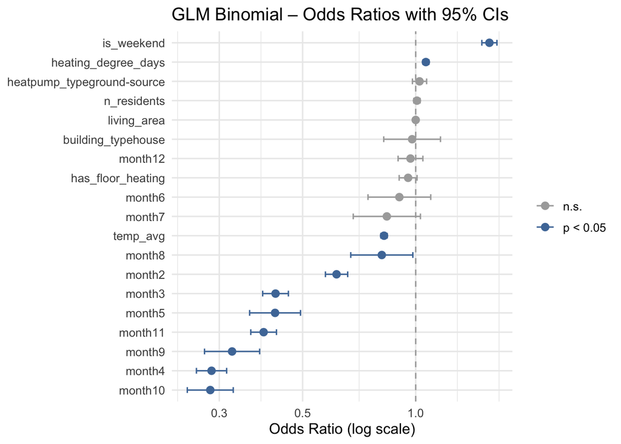

```r
coef_summary <- coef(summary(model_glm))
coef_df <- data.frame(
  term = rownames(coef_summary),
  estimate = coef_summary[, "Estimate"],
  se = coef_summary[, "Std. Error"],
  p_value = coef_summary[, "Pr(>|z|)"]
) |>
  filter(term != "(Intercept)") |>
  mutate(
    odds_ratio = exp(estimate),
    ci_low = exp(estimate - 1.96 * se),
    ci_high = exp(estimate + 1.96 * se),
    significant = p_value < 0.05
  ) |>
  arrange(odds_ratio)

ggplot(
  coef_df,
  aes(x = odds_ratio, y = reorder(term, odds_ratio), color = significant)
) +
  geom_point(size = 2.5) +
  geom_errorbarh(aes(xmin = ci_low, xmax = ci_high), height = 0.3) +
  geom_vline(xintercept = 1, linetype = "dashed", color = clr_neutral) +
  scale_color_manual(
    values = c("FALSE" = clr_neutral, "TRUE" = clr_primary),
    labels = c("n.s.", "p < 0.05")
  ) +
  scale_x_log10() +
  labs(
    title = "GLM Binomial – Odds Ratios with 95% CIs",
    x = "Odds Ratio (log scale)",
    y = NULL,
    color = NULL
  ) +
  report_theme
```

The wide spread of odds ratios shows that calendar effects, particularly month dummies, drive the largest deviations from OR = 1, while structural household characteristics (building type, heat pump type) cluster near the reference line and are statistically non-significant, as expected by the modell setup.

The ROC curve traces the model’s sensitivity against its false positive rate as the classification threshold varies from 0 to 1. The dashed diagonal represents a model that predicts at random (AUC = 0.5). The further the blue curve bows toward the top-left corner, the better the model separates the two classes regardless of threshold choice.

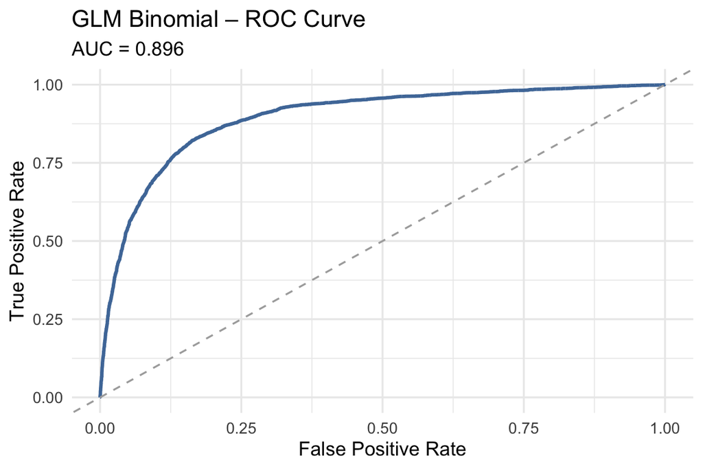

```r
roc_df <- (function(actual, prob) {
  ord <- order(prob, decreasing = TRUE)
  act <- actual[ord]
  n1 <- sum(act == 1)
  n0 <- sum(act == 0)
  data.frame(
    fpr = c(0, cumsum(act == 0) / n0),
    tpr = c(0, cumsum(act == 1) / n1)
  )
})(actual, pred_prob)

ggplot(roc_df, aes(x = fpr, y = tpr)) +
  geom_line(color = clr_primary, linewidth = 1) +
  geom_abline(
    slope = 1,
    intercept = 0,
    linetype = "dashed",
    color = clr_neutral
  ) +
  labs(
    title = "GLM Binomial – ROC Curve",
    subtitle = paste0("AUC = ", round(glm_auc_val, 3)),
    x = "False Positive Rate",
    y = "True Positive Rate"
  ) +
  report_theme
```

With an AUC of 0.896, the model correctly ranks a randomly drawn high-consumption day above a randomly drawn low-consumption day 89.6% of the time, which is a meaningful improvement over chance.

### 3.3.5 Model Diagnostics

The confusion matrix shows the model’s classifications on the held-out test set. The model correctly identifies 63.5% of true high- consumption days (sensitivity) and 92.6% of true low-consumption days (specificity). Because the per-household 75th percentile produces a 75/25 class split, a naive classifier that always predicts normal would achieve around 74.7% accuracy. The model’s accuracy of 85.2% is only 10.5 percentage points above this baseline, so AUC is the more informative metric.

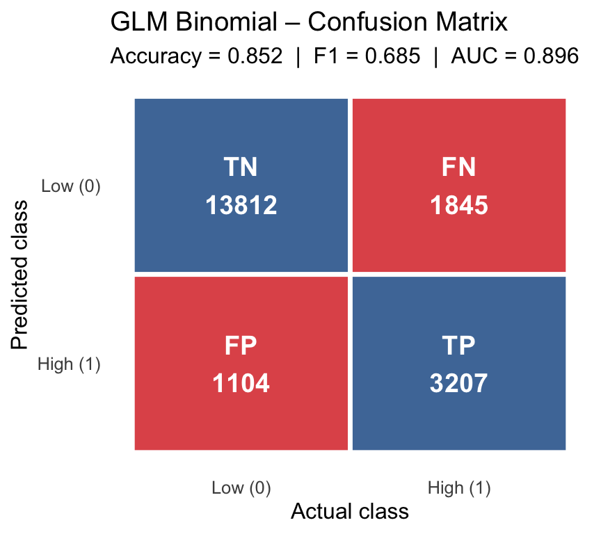

```r
conf_df <- data.frame(
  Predicted = factor(c("0", "0", "1", "1"), levels = c("1", "0")),
  Actual = factor(c("0", "1", "0", "1"), levels = c("0", "1")),
  Count = c(tn, fn, fp, tp),
  Label = c("TN", "FN", "FP", "TP")
)
ggplot(conf_df, aes(x = Actual, y = Predicted, fill = Label)) +
  geom_tile(color = "white", linewidth = 1.2) +
  geom_text(
    aes(label = paste0(Label, "\n", Count)),
    size = 5,
    fontface = "bold",
    color = "white"
  ) +
  scale_fill_manual(
    values = c(
      "TN" = clr_primary,
      "TP" = clr_primary,
      "FP" = clr_secondary,
      "FN" = clr_secondary
    )
  ) +
  scale_x_discrete(labels = c("0" = "Low (0)", "1" = "High (1)")) +
  scale_y_discrete(labels = c("0" = "Low (0)", "1" = "High (1)")) +
  labs(
    title = "GLM Binomial – Confusion Matrix",
    subtitle = paste0(
      "Accuracy = ",
      round(accuracy, 3),
      "  |  F1 = ",
      round(f1, 3),
      "  |  AUC = ",
      round(glm_auc_val, 3)
    ),
    x = "Actual class",
    y = "Predicted class",
    fill = "Count"
  ) +
  report_theme +
  theme(legend.position = "none", panel.grid = element_blank())
```

The remaining errors occur mainly on days where consumption is only marginally above or below the household’s personal threshold and therefore genuinely ambiguous. The F1 score of 0.685 summarises the balance between precision and recall into a single number, useful here because the 75/25 class split means accuracy alone is misleading. The AUC of 0.896 measures the model’s ability to rank a randomly drawn high-consumption day above a randomly drawn low-consumption day, regardless of the classification threshold chosen. Together, F1 and AUC confirm that the model performs well beyond what the modest accuracy gain over the naive baseline suggests.

### 3.3.6 Key Findings

For the client, demand spikes at the household level are predictable from calendar and weather information alone, without needing to know anything about the household’s physical characteristics — structural variables lose significance once the model conditions on each household’s own baseline. The model is transparent, interpretable, and provides a well-founded baseline for comparison with more flexible classification methods.

## 3.4 Generalised Additive Model (GAM)

*Lead: Emanuel Lemma*

### 3.4.1 Objective

The Linear Model assumes that each predictor affects the response in a straight line. For energy consumption, this is often too rigid. The relationship between heating demand and electricity use may differ between houses and apartments, and between heat pump types, in ways that cannot be captured by fixed linear slopes. A Generalised Additive Model (GAM) relaxes this assumption by replacing fixed slopes with flexible smooth functions, while remaining fully interpretable through its component plots. Here we model `log_kWh_total` using exactly the same predictors as the extended Linear Model, namely heating degree days (interacted with building type and heat pump type), sunshine hours, humidity, living area, and the number of residents. The GAM replaces the LM’s explicit interaction terms with `by =` smooths, which allow the shape of the heating-demand curve to vary freely between groups. This makes the comparison between the two models direct and fair.

### 3.4.2 Model Setup

```r
df_gam <- heapo |>
  select(
    log_kWh_total,
    heating_degree_days,
    sunshine_hours,
    humidity_avg,
    living_area,
    building_type,
    heatpump_type,
    n_residents
  ) |>
  drop_na()

set.seed(42)
gam_train_idx <- sample(nrow(df_gam), 0.8 * nrow(df_gam))
gam_train <- df_gam[gam_train_idx, ]
gam_test <- df_gam[-gam_train_idx, ]
```

```r
if (!file.exists("../models/gam/gam_model_v2.rds")) {
  model_gam <- mgcv::gam(
    log_kWh_total ~
      s(heating_degree_days, by = building_type) +
      s(heating_degree_days, by = heatpump_type) +
      building_type +
      heatpump_type +
      s(sunshine_hours) +
      s(humidity_avg) +
      s(living_area) +
      n_residents,
    family = gaussian,
    data = gam_train
  )
  saveRDS(model_gam, "../models/gam/gam_model_v2.rds")
} else {
  model_gam <- readRDS("../models/gam/gam_model_v2.rds")
}
```

$$\begin{align}
\log(\text{kWh}_i) = \; & \alpha + \beta_1 \text{building type}_i +
\beta_2 \text{heatpump type}_i + \beta_3 \text{n residents}_i \\
& + s(\text{HDD}_i \mid \text{building type}_i) + s(\text{HDD}_i
\mid \text{heatpump type}_i) \\
& + s(\text{sunshine hours}_i) + s(\text{humidity avg}_i) +
s(\text{living area}_i) + \epsilon_i
\end{align}$$

### 3.4.3 Model Results

The table below summarises the estimated degrees of freedom, F-statistic and significance for each smooth term in the model.

**Show / hide table**

```r
s_gam <- summary(model_gam)
s_tab <- as.data.frame(s_gam$s.table)
s_tab <- cbind(Term = rownames(s_tab), s_tab)
knitr::kable(
  data.frame(
    Term = s_tab$Term,
    EDF = round(s_tab$edf, 1),
    F = round(s_tab$F, 2),
    p.value = formatC(s_tab[["p-value"]], digits = 3, format = "g")
  ),
  caption = "GAM – Smooth Terms",
  col.names = c("Smooth Term", "EDF", "F", "p-value"),
  row.names = FALSE
) %>%
  kable_styling(bootstrap_options = c("striped", "hover"), full_width = TRUE)
```

GAM – Smooth Terms

| Smooth Term | EDF | F | p-value |
| --- | --- | --- | --- |
| s(heating_degree_days):building_typeappartment | 0.8 | 1.34 | 0.316 |
| s(heating_degree_days):building_typehouse | 5.3 | 26.79 | 0 |
| s(heating_degree_days):heatpump_typeair-source | 1.7 | 10.64 | 1.38e-05 |
| s(heating_degree_days):heatpump_typeground-source | 1.3 | 5.43 | 0.00523 |
| s(sunshine_hours) | 6.5 | 34.95 | 0 |
| s(humidity_avg) | 5.3 | 1.69 | 0.118 |
| s(living_area) | 9.0 | 417.39 | 0 |

The smooth terms reveal where non-linearity is present in the data.

- **s(HDD):apartment (edf = 0.8):** The relationship is approximately linear and non-significant (p = 0.316). The wide confidence band likely reflects the limited number of apartment observations in the dataset rather than genuine ambiguity about the functional form. The data do not provide sufficient evidence to isolate a distinct heating response for apartments beyond the main HDD effect.
- **s(HDD):house (edf = 5.3):** Highly significant (p < 0.001) and strongly non-linear. For houses, the response to cold weather is strongly non-linear and highly certain, consumption accelerates disproportionately on the coldest days, meaning a simple straight-line assumption would underestimate peak heating demand.
- **s(HDD):air-source (edf = 1.7):** Air-source heat pumps show a near-linear but slightly curved response to heating demand, consumption rises steadily with cold weather with only a mild bend in the relationship.
- **s(HDD):ground-source (edf = 1.3):** Nearly linear and significant (p = 0.005). Ground-source heat pumps respond to cold weather in a stable and nearly linear fashion, making their consumption the most predictable of all groups.
- **s(sunshine_hours) (edf = 6.5):** Highly significant (p < 0.001) and strongly non-linear. More sunshine generally reduces consumption through passive solar gain, but the relationship is not a simple straight line. The effect levels off at moderate sunshine hours and rises again at very high values, suggesting that on the sunniest days some households switch their probably reversible heat pump to cooling mode, increasing electricity consumption.
- **s(humidity_avg) (edf = 5.3):** Non-linear in shape but not significant overall (p = 0.118). Humidity may interact with perceived temperature in ways not fully captured here. It is retained to enable a direct and controlled comparison between the LM and GAM on identical predictors. Dropping it did not meaningfully change the other coefficients.
- **s(living_area) (edf = 9.0):** Highly significant (p < 0.001) and the most non-linear term in the model. Consumption does not scale proportionally with floor area. The smooth suggests a complex pattern in the small-to-medium range (100–400 m²) that may partly reflect overfitting given the high edf. The dominant feature is a clear peak around 500–600 m² followed by a sharp decline at very large living areas. One possible explanation is more energy-efficient construction in larger or newer buildings, though this cannot be confirmed from the data alone.

The parametric terms capture the baseline level shifts between groups and are summarised in the table below.

```r
p_tab <- as.data.frame(s_gam$p.table)
p_tab <- cbind(Term = rownames(p_tab), p_tab)
knitr::kable(
  data.frame(
    Term = p_tab$Term,
    Est = round(p_tab$Estimate, 4),
    SE = round(p_tab[["Std. Error"]], 4),
    t.val = round(p_tab[["t value"]], 2),
    p.value = formatC(p_tab[["Pr(>|t|)"]], digits = 3, format = "g")
  ),
  caption = "GAM – Parametric Terms",
  col.names = c("Term", "Estimate", "Std. Error", "t-value", "p-value"),
  row.names = FALSE
) %>%
  kable_styling(bootstrap_options = c("striped", "hover"), full_width = TRUE)
```

GAM – Parametric Terms

| Term | Estimate | Std. Error | t-value | p-value |
| --- | --- | --- | --- | --- |
| (Intercept) | 2.5659 | 0.0331 | 77.62 | 0 |
| building_typehouse | 0.0192 | 0.0331 | 0.58 | 0.562 |
| heatpump_typeground-source | -0.1437 | 0.0065 | -22.09 | 8.13e-108 |
| n_residents | 0.1297 | 0.0030 | 43.62 | 0 |

- **Houses vs. apartments:** The parametric term for `building_typehouse` is small and not statistically significant (p = 0.562). Once the model fits a separate heating-demand curve per building type, the baseline intercept gap disappears. The difference between building types is captured entirely by how they respond to cold weather.
- **Ground-source vs. air-source heat pump:** Ground-source systems consume 13.4% less electricity per day, all else equal (p < 0.001). This large reduction reflects the inherently higher efficiency of ground-source heat pumps across all temperature conditions.
- **Number of residents:** Each additional resident adds 13.8% to daily consumption (p < 0.001), confirming that occupancy is a meaningful driver of electricity demand.

### 3.4.4 Visual Evidence

The component plots below visualise the estimated smooth function for each predictor, showing how each variable contributes to the predicted log consumption independently of the others.

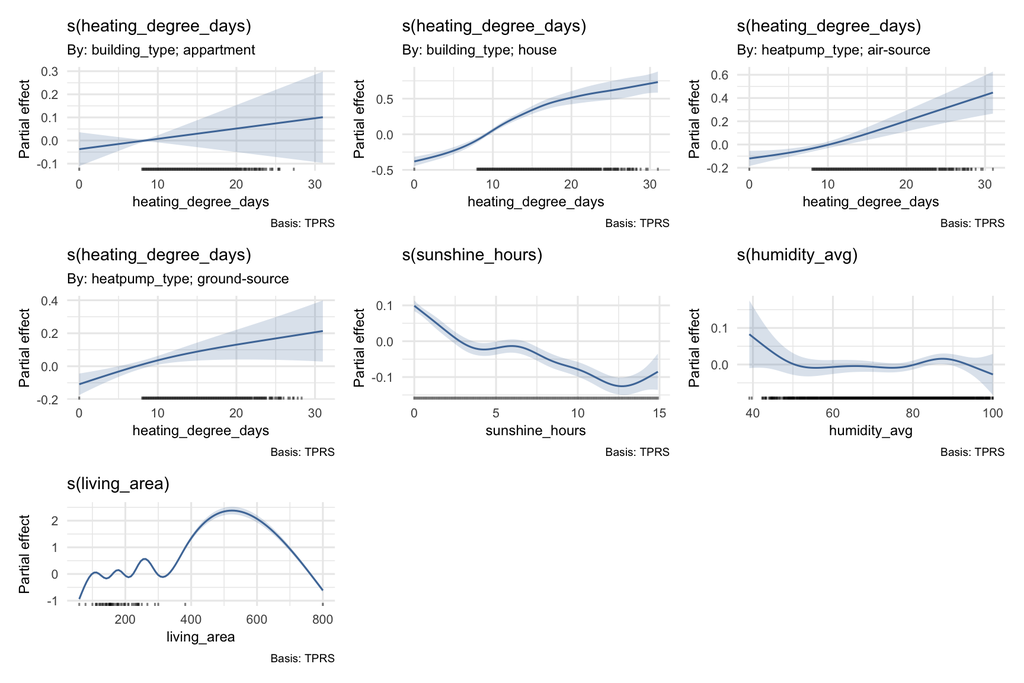

```r
gratia::draw(
  model_gam,
  residuals = FALSE,
  ci_level = 0.95,
  smooth_col = clr_primary,
  ci_col = clr_primary
) &
  report_theme &
  theme(
    text = element_text(size = 9),
    axis.text = element_text(size = 8),
    strip.text = element_text(size = 9)
  )
```

To make the by = smooths more interpretable, the plots below show the model’s predicted daily consumption on the original kWh scale, with all other predictors held at their median values.

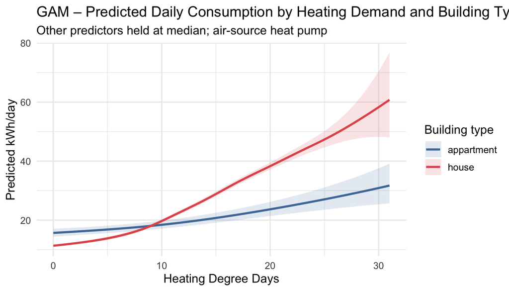

```r
hdd_grid <- expand.grid(
  heating_degree_days = seq(
    min(gam_train$heating_degree_days),
    max(gam_train$heating_degree_days),
    length.out = 200
  ),
  sunshine_hours = median(gam_train$sunshine_hours),
  humidity_avg = median(gam_train$humidity_avg),
  living_area = median(gam_train$living_area),
  n_residents = round(median(gam_train$n_residents)),
  building_type = levels(gam_train$building_type),
  heatpump_type = levels(gam_train$heatpump_type)[1]
)
hdd_pred <- predict(model_gam, newdata = hdd_grid, se.fit = TRUE)
hdd_grid$fit <- hdd_pred$fit
hdd_grid$se <- hdd_pred$se.fit

ggplot(
  hdd_grid,
  aes(
    x = heating_degree_days,
    y = exp(fit),
    color = building_type,
    fill = building_type
  )
) +
  geom_ribbon(
    aes(ymin = exp(fit - 1.96 * se), ymax = exp(fit + 1.96 * se)),
    alpha = 0.15,
    color = NA
  ) +
  geom_line(linewidth = 1) +
  labs(
    title = "GAM – Predicted Daily Consumption by Heating Demand and Building Type",
    subtitle = "Other predictors held at median; air-source heat pump",
    x = "Heating Degree Days",
    y = "Predicted kWh/day",
    color = "Building type",
    fill = "Building type"
  ) +
  scale_colour_manual(values = clr_builds) +
  scale_fill_manual(values = clr_builds) +
  report_theme
```

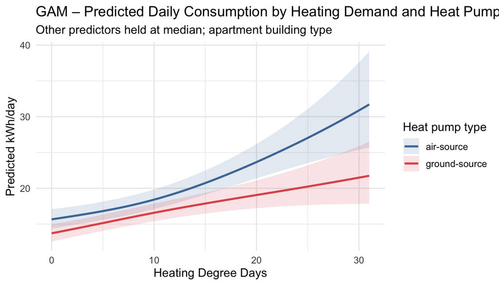

```r
hp_grid <- expand.grid(
  heating_degree_days = seq(
    min(gam_train$heating_degree_days),
    max(gam_train$heating_degree_days),
    length.out = 200
  ),
  sunshine_hours = median(gam_train$sunshine_hours),
  humidity_avg = median(gam_train$humidity_avg),
  living_area = median(gam_train$living_area),
  n_residents = round(median(gam_train$n_residents)),
  building_type = levels(gam_train$building_type)[1],
  heatpump_type = levels(gam_train$heatpump_type)
)
hp_pred <- predict(model_gam, newdata = hp_grid, se.fit = TRUE)
hp_grid$fit <- hp_pred$fit
hp_grid$se <- hp_pred$se.fit

ggplot(
  hp_grid,
  aes(
    x = heating_degree_days,
    y = exp(fit),
    color = heatpump_type,
    fill = heatpump_type
  )
) +
  geom_ribbon(
    aes(ymin = exp(fit - 1.96 * se), ymax = exp(fit + 1.96 * se)),
    alpha = 0.15,
    color = NA
  ) +
  geom_line(linewidth = 1) +
  labs(
    title = "GAM – Predicted Daily Consumption by Heating Demand and Heat Pump Type",
    subtitle = "Other predictors held at median; apartment building type",
    x = "Heating Degree Days",
    y = "Predicted kWh/day",
    color = "Heat pump type",
    fill = "Heat pump type"
  ) +
  scale_colour_manual(
    values = c("air-source" = clr_primary, "ground-source" = clr_secondary)
  ) +
  scale_fill_manual(
    values = c("air-source" = clr_primary, "ground-source" = clr_secondary)
  ) +
  report_theme
```

### 3.4.5 Model Diagnostics

The plots below assess how well the model fits the training data and whether any systematic patterns remain in the residuals.

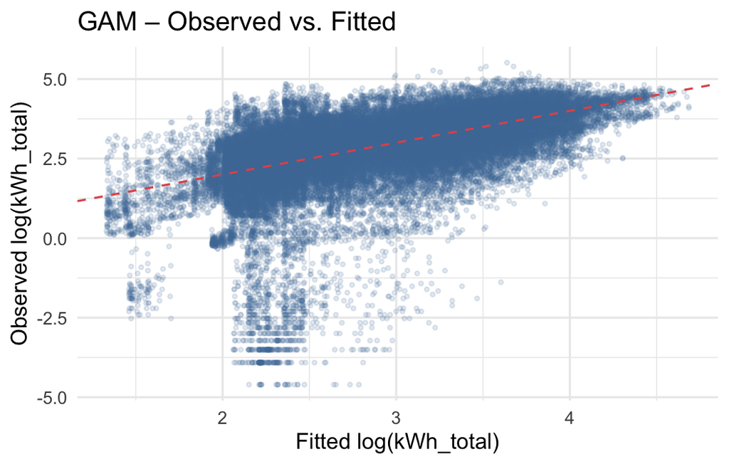

```r
fit_df <- data.frame(
  observed = gam_train$log_kWh_total,
  fitted = fitted(model_gam)
)
ggplot(fit_df, aes(x = fitted, y = observed)) +
  geom_point(alpha = 0.15, size = 0.8, color = clr_primary) +
  geom_abline(
    intercept = 0,
    slope = 1,
    color = clr_secondary,
    linetype = "dashed"
  ) +
  labs(
    title = "GAM – Observed vs. Fitted",
    x = "Fitted log(kWh_total)",
    y = "Observed log(kWh_total)"
  ) +
  report_theme
```

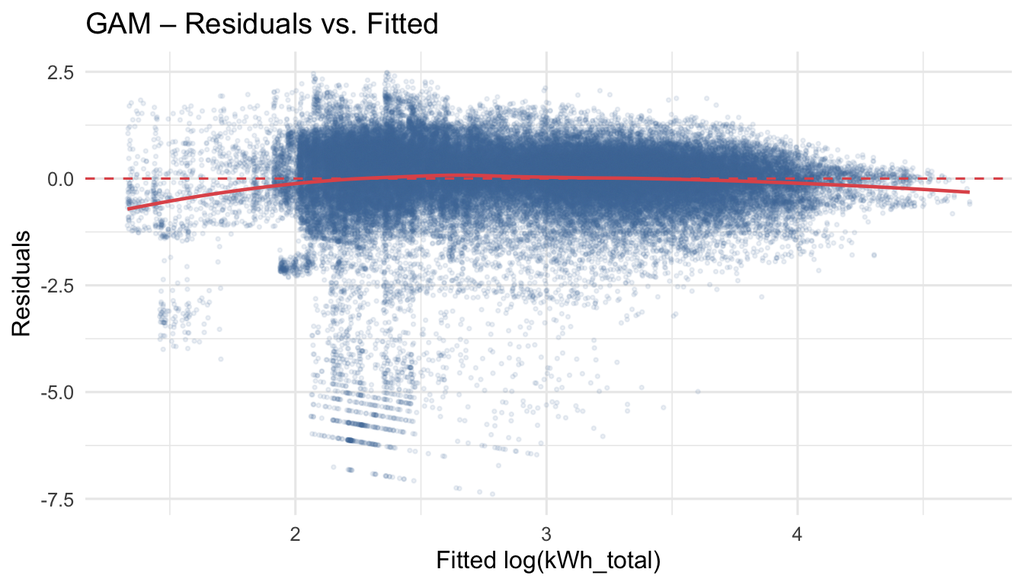

```r
resid_df <- data.frame(
  fitted = fitted(model_gam),
  residuals = residuals(model_gam)
)
ggplot(resid_df, aes(x = fitted, y = residuals)) +
  geom_point(alpha = 0.1, size = 0.6, color = clr_primary) +
  geom_hline(yintercept = 0, color = clr_secondary, linetype = "dashed") +
  geom_smooth(
    method = "loess",
    se = FALSE,
    color = clr_secondary,
    linewidth = 0.8
  ) +
  labs(
    title = "GAM – Residuals vs. Fitted",
    x = "Fitted log(kWh_total)",
    y = "Residuals"
  ) +
  report_theme
```

**Show / hide result**

```
## R² (test):          31.6%
## MAE (kWh/day):     10.6 kWh
## Median consumption: 20.9 kWh/day
## MAE as % of median: 50.5%
```

The most interpretable performance metric here is the mean absolute error in kWh. On average, the model’s daily consumption forecasts are off by 10.6 kWh, against a median household consumption of 20.9 kWh/day. This means a typical prediction error of about 51% of a household’s usual daily consumption. This is expected for a cross-sectional model of this type. Weather and building characteristics capture the structural drivers of demand, but day-to-day variation driven by individual behaviour, whether someone is home, what appliances they use, is simply not observable from the available predictors and represents a natural ceiling for this modelling approach.

A note on why RMSE was not used. RMSE on the log scale is mathematically correct but has no intuitive unit that a client can relate to. MAE in kWh is directly actionable, and R² communicates model quality in plain percentage terms.

### 3.4.6 Key Findings

- **Heating demand (HDD)** is non-linear for houses (edf = 5.3, p < 0.001), meaning the LM’s linear interaction term understates the acceleration in consumption during the coldest days.
- **HDD for apartments** shows no significant smooth effect (edf = 0.8, p = 0.316). Apartment consumption responds to cold weather in a way that is well described by a straight line once group-specific curves are allowed. The extended LM captures those effects adequately.
- **Ground-source heat pumps** consume 13.4% less electricity than air-source systems (p < 0.001).
- **Each additional resident** adds 13.8% to daily consumption (p < 0.001).
- **Living area** is the most non-linear predictor (edf = 9.0, p < 0.001). Consumption does not scale proportionally with floor area.
- The GAM achieves an R² of 31.6% and a MAE of 10.6 kWh/day, improving on the extended LM by about 0.4 kWh/day. This modest gain does not justify choosing the GAM over the LM when interpretability is the priority. The detailed comparison using 5-fold cross-validation is presented in the Model Comparison section.

## 3.5 Neural Network (NN)

*Lead: Raphaël Spagolla*

### 3.5.1 Objective

The aim of this analysis is to predict whether an observation corresponds to a high-consumption event (high_consumption), a binary outcome taking values 0 or 1. This is a classification problem, where the focus is on accurately distinguishing between high- and low-consumption cases.

From a practical perspective, reliable classification of high-consumption events can support decision-making processes such as resource allocation, cost management, or demand planning. Early identification of such events allows for more efficient operational responses.

A neural network is employed to capture potentially complex and non-linear relationships between consumption and predictors, including weather conditions, building characteristics, and household composition. Model performance is evaluated based on predictive accuracy and classification metrics derived from test data.

### 3.5.2 Data Preparation

The dataset consists of 99,838 observations and includes variables related to weather conditions, building characteristics, and household composition. The response variable, *high_consumption*, is binary, defined using each household’s own 75th percentile of `log_kWh_total` as the threshold — consistent with the GLM Binomial and SVM. By construction, exactly 25% of each household’s days are classified as high-consumption.

To ensure valid model evaluation, the data is split into training (80%) and test (20%) sets using a stratified sampling approach. This preserves the class distribution in both subsets and avoids biased performance estimates that could arise from imbalanced splits.

Categorical variables are transformed into dummy variables using one-hot encoding, allowing them to be used as inputs in the neural network. In addition, all predictors are scaled based on the training data. This step is important for neural networks, as it improves numerical stability and facilitates efficient training. The same transformations are then applied to the test set to ensure consistency and prevent data leakage.

### 3.5.3 Model Setup

**Show / hide result**

```r
cat(deparse(formula(mod_nn)), "\n\n")
```

```
## high_consumption ~ heating_degree_days + temp_avg + living_area +      building_typehouse + heatpump_typeground.source + has_floor_heating1 +      n_residents + is_weekend1
```

```r
mod_nn$call
```

```
## nnet.formula(formula = high_consumption ~ ., data = train_nn,
##     size = 25, decay = 0.05, maxit = 1000, trace = FALSE)
```

A non-linear activation function is applied in the hidden layer, enabling the model to learn complex patterns in the data. The output layer produces predicted probabilities for the high-consumption class.

To improve generalisation, weight decay (set to 0.05) is included as a regularisation mechanism. This penalises large weights and helps reduce model variance. The network is trained using the nnet package with a sufficient number of iterations to ensure convergence.

Overall, the chosen specification reflects a trade-off between predictive performance and model stability, favouring a parsimonious architecture that performs reliably on unseen data.

### 3.5.4 Model Results

**Show / hide result**

```r
truth <- test_nn$high_consumption
pred_class <- factor(
  ifelse(pred_prob_1 >= 0.5, "1", "0"),
  levels = levels(truth)
)

cm <- table(Predicted = pred_class, Actual = truth)
acc <- mean(pred_class == truth)
tp <- cm["1", "1"]
tn <- cm["0", "0"]
fp <- cm["1", "0"]
fn <- cm["0", "1"]
sensitivity <- tp / (tp + fn)
specificity <- tn / (tn + fp)

# ROC object (used by plots below)
pred_roc <- ROCR::prediction(pred_prob_1, truth)
perf_roc <- ROCR::performance(pred_roc, "tpr", "fpr")
nn_auc_val <- round(
  as.numeric(ROCR::performance(pred_roc, "auc")@y.values[[1]]),
  3
)

knitr::kable(
  data.frame(
    Model = "Neural Network",
    Accuracy = round(acc, 3),
    Sensitivity = round(sensitivity, 3),
    Specificity = round(specificity, 3),
    AUC = nn_auc_val
  ),
  caption = "Neural Network Performance Metrics"
) %>%
  kable_styling(bootstrap_options = c("striped", "hover"), full_width = TRUE)
```

Neural Network Performance Metrics

| Model | Accuracy | Sensitivity | Specificity | AUC |
| --- | --- | --- | --- | --- |
| Neural Network | 0.855 | 0.621 | 0.934 | 0.91 |

The neural network achieves an accuracy of approximately 0.86. Because the binary target is defined using the 75th-percentile threshold, roughly 75% of observations belong to the low-consumption class; a naive classifier that always predicts “low” would therefore achieve a baseline accuracy of $\approx 0.75$. The model’s accuracy must be assessed against this higher bar rather than a 50/50 split. The AUC of 0.91 provides a threshold-independent measure and confirms discriminative ability beyond the class-imbalance baseline.

Specificity (0.934) exceeds sensitivity (0.621), indicating that the model is more effective at identifying low-consumption days than high-consumption days. This is expected given the 75/25 class imbalance: with three times as many normal days as high-consumption days, the model has more signal for the majority class. The lower sensitivity reflects a higher rate of missed high-consumption events, which is the more costly error in capacity-planning contexts.

Overall, the confusion matrix shows that the majority of observations are correctly classified, with most predictions concentrated along the diagonal. However, misclassifications occur in both directions, indicating that some observations share similar characteristics across classes.

These results indicate good overall classification performance, although some variability remains unexplained, likely due to overlap in predictor patterns between the two classes.

### 3.5.5 Visual Evidence

The *predicted probability plot* illustrates how the neural network separates the two classes. Observations belonging to the high-consumption class tend to have higher predicted probabilities, while low-consumption cases are concentrated at lower values. However, noticeable overlap in the mid-range indicates that some observations cannot be clearly distinguished, which explains the presence of classification errors.

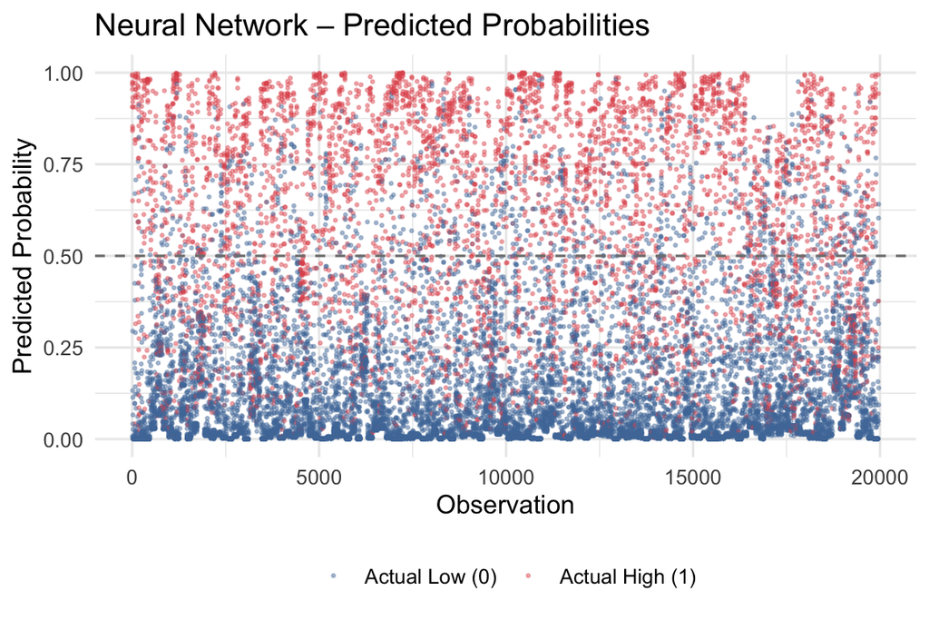

```r
nn_prob_df <- data.frame(
  index = seq_along(pred_prob_1),
  probability = as.numeric(pred_prob_1),
  actual = as.character(truth)
)

ggplot(nn_prob_df, aes(x = index, y = probability, color = actual)) +
  geom_point(alpha = 0.4, size = 0.4) +
  geom_hline(yintercept = 0.5, linetype = "dashed", color = "grey50") +
  scale_color_manual(
    values = c("0" = clr_primary, "1" = clr_secondary),
    labels = c("0" = "Actual Low (0)", "1" = "Actual High (1)")
  ) +
  labs(
    title = "Neural Network – Predicted Probabilities",
    x = "Observation",
    y = "Predicted Probability",
    color = NULL
  ) +
  report_theme +
  theme(legend.position = "bottom")
```

The *confusion matrix* provides a direct summary of classification performance. Most observations lie on the diagonal, confirming a high number of correct predictions for both classes. Nevertheless, errors occur in both directions, highlighting that class separation is not complete.

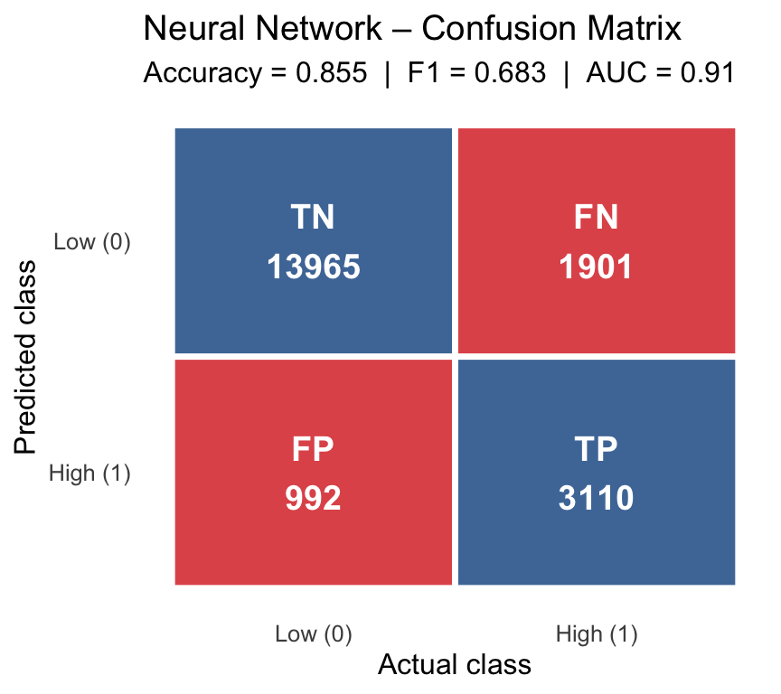

```r
nn_df <- data.frame(
  Predicted = factor(c("0", "0", "1", "1"), levels = c("1", "0")),
  Actual = factor(c("0", "1", "0", "1"), levels = c("0", "1")),
  Count = c(cm["0", "0"], cm["0", "1"], cm["1", "0"], cm["1", "1"]),
  Label = c("TN", "FN", "FP", "TP")
)

ggplot(nn_df, aes(x = Actual, y = Predicted, fill = Label)) +
  geom_tile(color = "white", linewidth = 1.2) +
  geom_text(
    aes(label = paste0(Label, "\n", Count)),
    size = 5,
    fontface = "bold",
    color = "white"
  ) +
  scale_fill_manual(
    values = c(
      "TN" = clr_primary,
      "TP" = clr_primary,
      "FP" = clr_secondary,
      "FN" = clr_secondary
    )
  ) +
  scale_x_discrete(labels = c("0" = "Low (0)", "1" = "High (1)")) +
  scale_y_discrete(labels = c("0" = "Low (0)", "1" = "High (1)")) +
  labs(
    title = "Neural Network – Confusion Matrix",
    subtitle = paste0(
      "Accuracy = ",
      round(acc, 3),
      "  |  F1 = ",
      round(
        2 *
          (tp / (tp + fp)) *
          (tp / (tp + fn)) /
          ((tp / (tp + fp)) + (tp / (tp + fn))),
        3
      ),
      "  |  AUC = ",
      nn_auc_val
    ),
    x = "Actual class",
    y = "Predicted class"
  ) +
  report_theme +
  theme(legend.position = "none", panel.grid = element_blank())
```

The *ROC curve* further evaluates model performance across all possible classification thresholds. The curve lies clearly above the diagonal reference line, indicating strong discriminative ability and performance well above random classification. The steep initial increase suggests that high true positive rates can be achieved with relatively low false positive rates, while the flattening at higher values reflects diminishing gains.

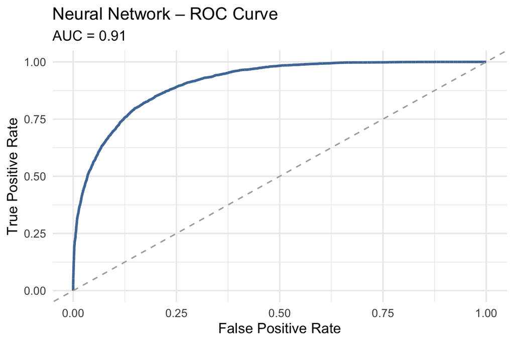

```r
roc_df_nn <- data.frame(
  fpr = perf_roc@x.values[[1]],
  tpr = perf_roc@y.values[[1]]
)

ggplot(roc_df_nn, aes(x = fpr, y = tpr)) +
  geom_line(color = clr_primary, linewidth = 1) +
  geom_abline(
    slope = 1,
    intercept = 0,
    linetype = "dashed",
    color = clr_neutral
  ) +
  labs(
    title = "Neural Network – ROC Curve",
    subtitle = paste0("AUC = ", nn_auc_val),
    x = "False Positive Rate",
    y = "True Positive Rate"
  ) +
  report_theme
```

### 3.5.6 Model Diagnostics

The ROC curve confirms consistent performance across classification thresholds and a clear improvement over random classification. However, the observed overlap in predicted probabilities indicates that the available predictors do not fully separate the two classes. This suggests that model performance is constrained more by the information content of the data than by the chosen model structure.

### 3.5.7 Coefficient Interpretation

Neural network weights are not directly interpretable as coefficients. Because inputs pass through non-linear transformations across multiple layers, no single weight carries an isolated, meaningful effect. Model performance metrics (AUC, accuracy) and the cross-validation comparison in the Model Comparison section serve as the practical evaluation instead.

### 3.5.8 Key Findings

- The neural network achieves solid predictive performance and successfully captures non-linear relationships in the data. Accuracy is approximately 85.5%, above the $\approx 75$% naive baseline arising from the 75/25 class split, though the margin is modest.
- The model is more effective at identifying low-consumption days than high- consumption days, as reflected in higher specificity compared to sensitivity. This is expected given the 75/25 class imbalance.
- The confusion matrix and ROC curve confirm good overall classification ability, although not perfect.
- Overlap in predicted probabilities indicates that some observations cannot be clearly separated, limiting maximum achievable performance.
- Increasing model complexity does not lead to substantial improvements, suggesting that performance is primarily constrained by the available features rather than the model itself.

From a practical perspective, the model can serve as a useful decision-support tool for identifying high-consumption events, although predictions should be interpreted with some caution due to remaining classification uncertainty. Further improvements are more likely to come from enhanced feature engineering or the inclusion of additional relevant variables. Cross-validation results for the Neural Network are reported in the Model Comparison section.

## 3.6 Support Vector Machine (SVM)

*Lead: Tharrmeehan Krishnathasan*

```r
hh_q75_svm <- heapo |>
  group_by(Household_ID) |>
  summarise(
    hh_q75 = quantile(log_kWh_total, 0.75, na.rm = TRUE),
    .groups = "drop"
  )

heapo_svm_data <- heapo |>
  left_join(hh_q75_svm, by = "Household_ID") |>
  mutate(
    high_consumption = as.factor(
      ifelse(log_kWh_total >= hh_q75, "high", "normal")
    )
  ) |>
  select(
    high_consumption,
    heating_degree_days,
    sunshine_hours,
    humidity_avg,
    living_area,
    n_residents,
    building_type,
    heatpump_type
  ) |>
  na.omit()

set.seed(42)
train_idx <- createDataPartition(
  heapo_svm_data$high_consumption,
  p = 0.8,
  list = FALSE
)
train_data <- heapo_svm_data[train_idx, ]
test_data <- heapo_svm_data[-train_idx, ]
test_x <- test_data |> select(-high_consumption)
test_y <- test_data$high_consumption

# Baseline SVM: C=1, sigma estimated from training data via sigest.
# Cached to heapo_svm_baseline_hh_q75.rds so subsequent knits skip refit.
if (!file.exists("../models/svm/heapo_svm_baseline_hh_q75.rds")) {
  svm_baseline <- kernlab::ksvm(
    high_consumption ~ .,
    data = train_data,
    kernel = "rbfdot",
    C = 1,
    kpar = "automatic",
    scaled = TRUE
  )
  saveRDS(svm_baseline, "../models/svm/heapo_svm_baseline_hh_q75.rds")
} else {
  svm_baseline <- readRDS("../models/svm/heapo_svm_baseline_hh_q75.rds")
}

# Tuned SVM: 5-fold CV grid search over C and sigma, same grid as original.
# Cached to heapo_svm_hh_q75.rds so subsequent knits skip refit.
if (!file.exists("../models/svm/heapo_svm_hh_q75.rds")) {
  tune_grid <- expand.grid(C = c(1, 10, 100), sigma = c(0.01, 0.1, 1 / 7))
  ctrl <- trainControl(method = "cv", number = 5)
  svm_caret <- train(
    high_consumption ~ .,
    data = train_data,
    method = "svmRadial",
    tuneGrid = tune_grid,
    trControl = ctrl,
    preProcess = c("center", "scale")
  )
  saveRDS(svm_caret, "../models/svm/heapo_svm_hh_q75.rds")
} else {
  svm_caret <- readRDS("../models/svm/heapo_svm_hh_q75.rds")
}

pred_best <- predict(svm_caret, test_x)
cm_best <- confusionMatrix(pred_best, test_y, positive = "high")

pred_baseline <- kernlab::predict(svm_baseline, test_x)
cm_baseline <- confusionMatrix(pred_baseline, test_y, positive = "high")

best_C <- svm_caret$bestTune$C
best_sigma <- round(svm_caret$bestTune$sigma, 4)

# 5-fold CV results (pre-computed by R/04_model_comparison_cv_classification.R)
if (file.exists("../models/cv_class_results.rds")) {
  cv_class <- readRDS("../models/cv_class_results.rds")
  svm_cv_row <- cv_class[grepl("SVM", cv_class$Model), ]
  svm_cv_auc <- svm_cv_row[["CV AUC"]]
  svm_cv_acc <- svm_cv_row[["CV Accuracy"]]
} else {
  svm_cv_auc <- NA
  svm_cv_acc <- NA
}
```

### 3.6.1 Objective

Can a high-load day be identified before it happens, using only weather conditions and what we already know about the household? This section trains a Support Vector Machine to classify each household-day as *high consumption* (top 25% of that household’s own days) or *normal*. The problem has direct operational relevance: a reliable early-warning classifier would let grid operators and energy providers plan capacity without waiting for demand spikes to appear on the meter.

An SVM is used because consumption peaks may not separate cleanly from normal days along a linear boundary. With a radial basis function (RBF) kernel, the model can find curved decision surfaces in high-dimensional feature space without making distributional assumptions about the predictors. A baseline model with default hyperparameters is compared against a tuned version where the regularisation strength C and kernel bandwidth sigma are selected by 5-fold cross-validation. The same per-household 75th percentile threshold used in the GLM Binomial is applied throughout, so the two classifiers can be compared directly on the same task.

### 3.6.2 Data Preparation

`high_consumption` labels a day as *high* if it falls in the top 25% of that household’s own `log_kWh_total` distribution. For each of the 127 households, the 75th percentile is computed separately, so every household contributes approximately 25% high-consumption days by construction.

After removing missing values, the dataset has 93,686 observations: 23,514 high-consumption days (25.1%) and 70,172 normal days (74.9%). `log_kWh_total` is excluded to prevent data leakage; the SVM must identify high-load days from weather and household characteristics alone.

The data are split 80/20 into training (74,950 rows) and test (18,736 rows) using stratified sampling to keep the class ratio consistent. All numeric predictors are standardised before training, as SVMs are sensitive to feature scale.

**Show / hide table**

```r
prop.table(table(train_data$high_consumption)) %>%
  as.data.frame() %>%
  rename(Class = Var1, Proportion = Freq) %>%
  mutate(Proportion = round(Proportion, 3)) %>%
  knitr::kable(
    caption = "Class balance in the training set"
  ) %>%
  kable_styling(bootstrap_options = c("striped", "hover"), full_width = TRUE)
```

Class balance in the training set

| Class | Proportion |
| --- | --- |
| high | 0.251 |
| normal | 0.749 |

### 3.6.3 Model Setup

**Baseline SVM:** C = 1, sigma estimated from training data. This provides a reference for the tuned model.

**Tuned SVM:** 5-fold cross-validation over a grid of `C` ∈ {1, 10, 100} and `sigma` ∈ {0.01, 0.1, 1/7}. `C` controls the misclassification penalty (higher = tighter fit); `sigma` is the inverse bandwidth of the RBF kernel (higher = more local boundaries). The combination with the highest CV accuracy is selected.

The best parameters were C = 100, sigma = 0.1429 (= 1/7), achieving CV accuracy of 0.8530 (Kappa = 0.5747) across the 3×3 grid.

### 3.6.4 Model Results

**Show / hide table**

```r
extract_metrics <- function(cm, model_name) {
  tibble(
    Model = model_name,
    Accuracy = round(cm$overall["Accuracy"], 4),
    Sensitivity = round(cm$byClass["Sensitivity"], 4),
    Specificity = round(cm$byClass["Specificity"], 4),
    `F1 Score` = round(cm$byClass["F1"], 4)
  )
}

bind_rows(
  extract_metrics(cm_baseline, "Baseline SVM (C=1, default sigma)"),
  extract_metrics(
    cm_best,
    paste0("Tuned SVM (C=", best_C, ", sigma=", best_sigma, ")")
  )
) %>%
  knitr::kable(
    caption = "SVM model comparison on test set"
  ) %>%
  kable_styling(bootstrap_options = c("striped", "hover"), full_width = TRUE)
```

SVM model comparison on test set

| Model | Accuracy | Sensitivity | Specificity | F1 Score |
| --- | --- | --- | --- | --- |
| Baseline SVM (C=1, default sigma) | 0.8512 | 0.5806 | 0.9419 | 0.6620 |
| Tuned SVM (C=100, sigma=0.1429) | 0.8529 | 0.5902 | 0.9409 | 0.6681 |

**Show / hide table**

```r
if (!is.na(svm_cv_auc)) {
  knitr::kable(
    data.frame(
      Model = paste0("Tuned SVM (C=", best_C, ", σ=", best_sigma, ")"),
      `CV AUC` = round(svm_cv_auc, 3),
      `CV Accuracy` = round(svm_cv_acc, 3),
      check.names = FALSE
    ),
    caption = "Tuned SVM — 5-fold cross-validation performance (per-household 75th percentile threshold)"
  ) %>%
    kable_styling(bootstrap_options = c("striped", "hover"), full_width = TRUE)
} else {
  cat(
    "*CV results not available. Run R/04_model_comparison_cv_classification.R first.*"
  )
}
```

Tuned SVM — 5-fold cross-validation performance (per-household 75th percentile threshold)

| Model | CV AUC | CV Accuracy |
| --- | --- | --- |
| Tuned SVM (C=100, σ=0.1429) | 0.842 | 0.831 |

The tuned SVM achieves a five-fold CV AUC of **0.842** and accuracy of **83.1%**. The test-set evaluation below reports sensitivity, specificity, and F1.

The tuned SVM (C = 100, sigma = 0.1429) reaches **85.3%** accuracy, compared to 85.1% for the baseline. The improvement is modest: a naive all-*normal* classifier would already score 74.9%, leaving a true gain of only 10 percentage points.

The more informative metrics are:

**Sensitivity (0.5902):** the model correctly identifies 59% of actual high-consumption days. Over 40% are still missed, a meaningful limitation in early-warning contexts where false negatives are costly.

**Specificity (0.9409):** normal days are classified correctly 94.1% of the time. The model is conservative, flagging fewer high-consumption days than actually occur (3605 predicted high vs. 4702 actual high in the test set).

**F1 Score (0.6681):** the harmonic mean of precision and recall for the high class reflects the imbalance between high specificity and low sensitivity.

**Kappa (0.5757):** moderate agreement beyond chance, improving on the baseline (0.569) but below the 0.6 threshold for *substantial* agreement.

### 3.6.5 Visual Evidence

The confusion matrix heatmap shows the full breakdown of test-set predictions against actual labels. Blue cells on the diagonal are correct predictions; red cells off the diagonal are errors. Reading column-wise gives the recall for each class; reading row-wise gives precision.

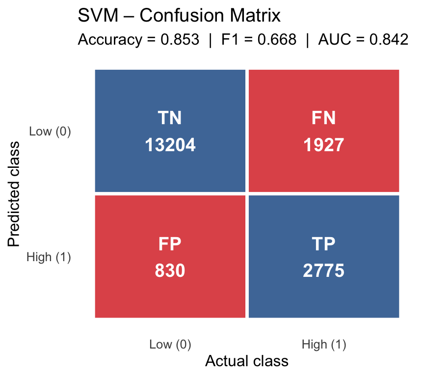

```r
cm_mat <- cm_best$table

svm_df <- data.frame(
  Predicted = factor(
    c("normal", "normal", "high", "high"),
    levels = c("high", "normal")
  ),
  Actual = factor(
    c("normal", "high", "normal", "high"),
    levels = c("normal", "high")
  ),
  Count = c(
    cm_mat["normal", "normal"],
    cm_mat["normal", "high"],
    cm_mat["high", "normal"],
    cm_mat["high", "high"]
  ),
  Label = c("TN", "FN", "FP", "TP")
)

ggplot(svm_df, aes(x = Actual, y = Predicted, fill = Label)) +
  geom_tile(color = "white", linewidth = 1.2) +
  geom_text(
    aes(label = paste0(Label, "\n", Count)),
    size = 5,
    fontface = "bold",
    color = "white"
  ) +
  scale_fill_manual(
    values = c(
      "TN" = clr_primary,
      "TP" = clr_primary,
      "FP" = clr_secondary,
      "FN" = clr_secondary
    )
  ) +
  scale_x_discrete(labels = c("normal" = "Low (0)", "high" = "High (1)")) +
  scale_y_discrete(labels = c("normal" = "Low (0)", "high" = "High (1)")) +
  labs(
    title = "SVM – Confusion Matrix",
    subtitle = paste0(
      "Accuracy = ",
      round(cm_best$overall["Accuracy"], 3),
      "  |  F1 = ",
      round(cm_best$byClass["F1"], 3),
      "  |  AUC = ",
      round(svm_cv_auc, 3)
    ),
    x = "Actual class",
    y = "Predicted class"
  ) +
  report_theme +
  theme(legend.position = "none", panel.grid = element_blank())
```

The matrix makes the model’s asymmetry concrete. The large TN count shows the SVM seldom raises false alarms on genuinely normal days, explaining the high specificity. The FN count (1,927) shows that over 40% of actual high-consumption days are silently missed. This conservative bias is a direct consequence of the 75/25 class split: on ambiguous days, the model defaults to the majority class.

The bar chart puts the sensitivity-specificity trade-off for both models side by side. Tuning from default parameters to C = 100, sigma = 0.1429 pushes sensitivity up from 58.1% to 59%, recovering more true high-consumption days at the cost of a small drop in specificity. The gain is consistent but modest, pointing to the predictor set rather than hyperparameter choice as the main constraint.

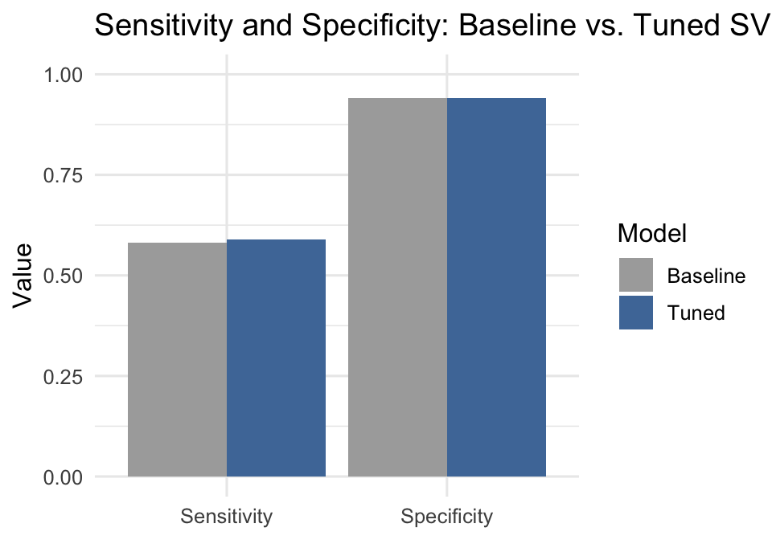

```r
metrics_df <- bind_rows(
  extract_metrics(cm_baseline, "Baseline"),
  extract_metrics(cm_best, "Tuned")
) %>%
  select(Model, Sensitivity, Specificity) %>%
  tidyr::pivot_longer(
    cols = c(Sensitivity, Specificity),
    names_to = "Metric",
    values_to = "Value"
  )

ggplot(metrics_df, aes(x = Metric, y = Value, fill = Model)) +
  geom_col(position = "dodge") +
  scale_fill_manual(
    values = c("Baseline" = clr_neutral, "Tuned" = clr_primary)
  ) +
  scale_y_continuous(limits = c(0, 1)) +
  report_theme +
  labs(
    title = "Sensitivity and Specificity: Baseline vs. Tuned SVM",
    x = NULL,
    y = "Value",
    fill = "Model"
  )
```

### 3.6.6 Model Diagnostics

Unlike regression models, SVM diagnostics focus on generalisation performance and modelling choices rather than distributional assumptions.

**CV tuning results:** Across all 9 combinations, CV accuracy ranged from 0.8488 (C=1, sigma=0.01) to 0.8530 (C=100, sigma=0.1429). The top four combinations all involve sigma ≥ 0.1, suggesting a moderately local kernel works best. The gain from C=10 to C=100 at sigma=0.1429 is small (0.8525 → 0.8530), pointing to the predictor set as the limiting factor rather than model configuration.

**Class separability:** The available predictors do not reliably separate the two classes. High and normal consumption days share substantial overlap in the feature space, which no kernel choice can resolve.

### 3.6.7 Key Findings

**The SVM achieves reasonable accuracy but low sensitivity:** At 85.3% accuracy, the model scores roughly 10 percentage points above the naive majority-class baseline (74.9%). Sensitivity of 59% is the bigger concern: over 40% of actual high-consumption days are missed, while specificity of 94.1% shows the model rarely raises false alarms on normal days. This makes it too conservative on its own for capacity planning or demand-response triggering.

**Tuning yields real but limited improvement:** Moving from default parameters to C=100, sigma=0.1429 improves sensitivity from 58.1% to 59% and accuracy from 85.1% to 85.3%. The gains are consistent but small; further tuning will not resolve the core problem.

**The predictor set is the bottleneck:** Weather conditions and static household characteristics capture only part of what drives high-consumption days. High and normal consumption days overlap substantially in the feature space, and no kernel or regularisation choice can separate what is genuinely mixed in the data. Richer features would help: lagged consumption, occupancy patterns, or appliance-level data.

**Threshold adjustment is a practical alternative:** Lowering the flagging threshold would recover more true positives at the cost of more false alarms, which may be acceptable in a probabilistic forecasting pipeline. At the default threshold, the model should not be the sole basis for high-consumption day decisions.

# 4 Model Comparison

The six models do not all share the same response variable, so a single unified comparison table is not possible. Instead, models are grouped by what they predict. Regression models (LM and GAM) are evaluated on `log_kWh_total` using five-fold cross-validation mean absolute error in kWh and R². Classification models (GLM Binomial, Neural Network, SVM) are evaluated on `high_consumption` using five-fold CV AUC and accuracy. The GLM Poisson targets a monthly count at a different aggregation level and is assessed separately. In all cases, the same random fold assignment is used across models within each group so that fold-to-fold variation cancels out and differences reflect only model quality.

## 4.1 Regression Models: LM vs GAM

The table below reports five-fold cross-validation performance for the two regression models fitted to `log_kWh_total`. MAE is computed on the original kWh scale for interpretability. R² is computed on the log scale.

Five-fold CV performance: regression models on log_kWh_total. MAE is on the kWh scale; R² is on the log scale.

| Model | CV MAE (kWh/day) | CV R2 |
| --- | --- | --- |
| Linear Model (extended) | 10.96 | 0.274 |
| GAM (same predictors) | 10.56 | 0.310 |

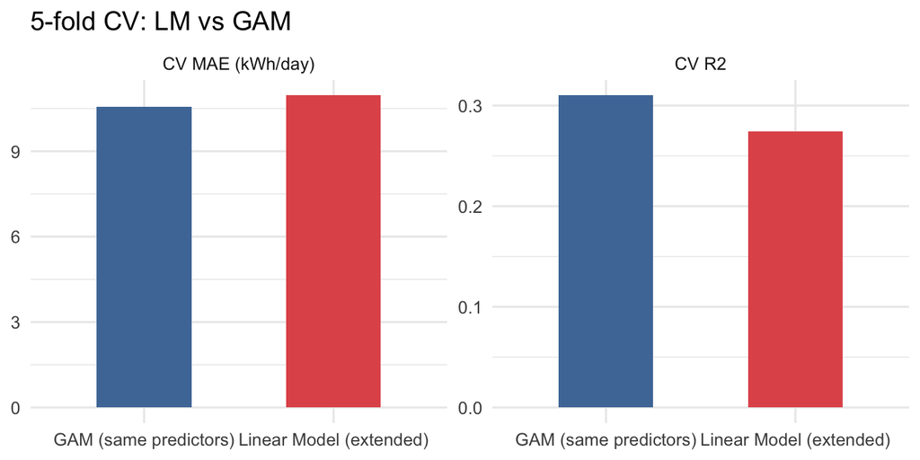

Both models use **exactly the same predictor set**: heating degree days (interacted with building type and heat pump type), sunshine hours, humidity, living area, and number of residents. The only difference is functional form: the LM uses linear terms and explicit interaction dummies, while the GAM replaces these with `by =` smooths. This makes the comparison controlled and directly attributable to model flexibility rather than predictor choice.

The GAM achieves a CV MAE of 10.56 kWh/day and an R² of 0.31, compared to 10.96 kWh/day and R² of 0.274 for the extended LM. The GAM reduces prediction error by 0.4 kWh/day, a roughly 3.6% improvement, and explains 3.6 additional percentage points of variance. The improvement is real but modest. As the GAM smooth plots showed, the main non-linearity is in how houses respond to extreme cold (edf = 5.3 for s(HDD):house), but this effect does not translate into a large out-of-sample accuracy gain. This suggests that household-level heterogeneity, not functional form, is the primary source of unexplained variance.

For a client who prioritises interpretability, the extended LM is a reasonable choice: its coefficients are directly actionable and its predictions are nearly as accurate. For a client who prioritises predictive performance, the GAM is preferred, but the marginal gain of 0.40 kWh/day should be weighed against the added complexity of smooth terms and the loss of a single interpretable coefficient per predictor.

## 4.2 Classification Models: GLM Binomial vs SVM vs Neural Network

The table below compares all three classification models. All three use each household’s own 75th percentile as the high-consumption threshold, making results directly comparable. CV results are available for all three models.

Classification model performance. All models: 5-fold CV, per-household 75th percentile threshold.

| Model | CV AUC | CV Accuracy |
| --- | --- | --- |
| GLM Binomial | 0.830 | 0.802 |
| SVM (C=100, σ=0.1429) | 0.842 | 0.831 |
| Neural Network | 0.908 | 0.855 |

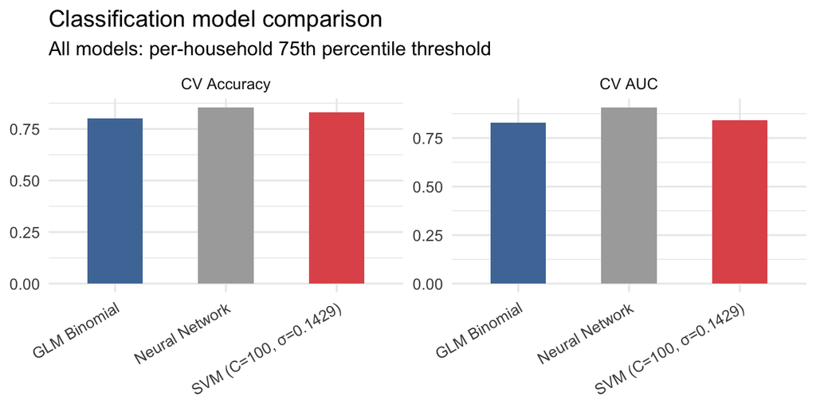

## 4.3 GLM Poisson (Standalone)

The GLM Poisson models `n_high_days` at the household–month level and cannot be placed in either comparison table. It is evaluated separately via five-fold CV RMSE on the count scale.

```r
set.seed(42)

# Extract formula cleanly — detach from model environment to avoid memory bleed
cv_form <- as.formula(
  deparse(formula(mod_pois)),
  env = baseenv()
)

n <- nrow(dat_count)
folds <- sample(rep(1:5, length.out = n))
rmse_folds <- numeric(5)

for (k in 1:5) {
  train_k <- dat_count[folds != k, ]
  test_k <- dat_count[folds == k, ]

  fit_k <- glm(
    cv_form,
    family = poisson(link = "log"),
    offset = log(n_days),
    data = train_k,
    model = FALSE,
    x = FALSE,
    y = FALSE
  )

  pred_k <- predict(fit_k, newdata = test_k, type = "response")
  rmse_folds[k] <- sqrt(mean((test_k$n_high_days - pred_k)^2))
  rm(fit_k, train_k, test_k)
  gc()
}

pois_cv_rmse <- round(mean(rmse_folds), 3)
pois_cv_sd <- round(sd(rmse_folds), 3)
```

The five-fold CV RMSE is 9.48 days (SD = 0.31). Given that `n_high_days` ranges from 0 to ~30, this reflects moderate prediction error on the count scale.

**Limitation.** This RMSE is not directly comparable to any other metric in this report: the unit of observation is a household–month and the response is a raw count. Cross-model ranking would be misleading.

Across all six models, interpretability and predictive performance trade off consistently. The LM, GAMs, and GLM Poisson offer transparent, coefficient-based explanations but leave more variance unexplained. The SVM and Neural Network improve accuracy but are effectively black boxes. The GLM Binomial offers a middle ground, with interpretable log-odds coefficients and competitive classification performance. The right choice depends on whether the use case demands explainability or accuracy.

# 5 Conclusions

Across 127 Swiss households monitored daily from 2022 to 2024, this analysis identified the key drivers of heat pump electricity consumption and built a foundation for demand modelling relevant to grid operators and energy suppliers.

Cold weather is the strongest structural driver of daily consumption, but its effect is not uniform. Houses show a sharply accelerating response on the coldest winter days, a pattern that has direct implications for load forecasting during cold snaps and that a plain linear model understates. Beyond weather, heat pump type and occupancy are the two most consistent predictors across all models. Ground-source heat pumps consume approximately 13% less electricity per day than air-source systems, and every additional resident adds roughly 14% to daily demand regardless of building type or season.

For classifying unusually high-demand days, weekend occupancy is the single strongest predictor, with cold weather second. Structural characteristics become non-significant once the model accounts for each household’s own baseline, meaning demand spikes are driven by behaviour and weather rather than building or system properties.

The GAM achieved the best predictive accuracy for daily consumption with a MAE of 10.6 kWh per day and an R² of 31%, modestly improving on the Linear Model. Both models leave roughly two thirds of day-to-day variation unexplained, pointing to the value of incorporating behavioural signals in future work. For classification, the Neural Network achieved the strongest performance with an AUC of 0.908 and accuracy of 85.5%, with the SVM close behind at an AUC of 0.842 and accuracy of 83.1%. For a client prioritising transparency, the GLM Binomial is recommended, achieving an AUC of 0.83 and accuracy of 80.2% while remaining fully interpretable and maintainable since less parameters are needed.

The practical implication for energy suppliers and grid operators is to target demand management programmes at larger households with air-source systems during cold weather peaks, where high occupancy and less efficient heating combine to produce the sharpest load spikes. Weekend time-of-use tariffs or demand response incentives offer an additional lever for flattening these peaks and reducing balancing energy costs. Since the model can flag high-demand days in advance, proactive communication to at-risk households before cold snaps represents a low-cost first step. At the grid level, aggregating flexibility across many heat pump households into a virtual power plant would allow suppliers to collectively shift or pause demand during price spikes. The findings here provide a basis for identifying which households offer the most relevant flexibility. For households currently considering a heat pump installation, ground-source systems show consistently lower consumption and should be recommended where feasible. Promoting energy storage and load-shifting solutions could further reduce reliance on the spot market, though further research is needed to quantify the long-term financial benefit across all these approaches.

# 6 Use of Generative AI

Generative AI tools, primarily Claude (Anthropic) and GitHub Copilot, were used throughout this project to support code generation, debugging, and text drafting. AI assistance proved effective for producing boilerplate R code for data preprocessing, visualisation, and model-fitting wrappers, as well as for generating first drafts of methodological prose describing model outputs and statistical concepts. Human oversight was essential for tasks requiring analytical judgement, including the selection of modelling thresholds, cross-validation architecture, and the interpretation of model coefficients, where AI-generated suggestions occasionally contained subtle errors or overstated certainty. All AI-generated code was reviewed and tested prior to integration, and all interpretive text was verified against actual model output before inclusion in this report.